# Rcode_NCWW_Manuscript

Mengyi Dong

2025-02-10

#This is a code document for all the analysis performed in the manuscript. #Load library

```r
set.seed(001)
library(phyloseq)
library("vegan")
```

```r
library(ggplot2)
library(ggpubr)
library(RColorBrewer)
library(tidyr)
library(dplyr)
library(ape)
library(microbiome)
library(stats)
library(PathoStat)
library(here)
library(ggthemes)
library(tibble)
library(textshape)
library(envalysis)
library(vegan3d)
library(scatterplot3d)
```

#Load phyloseq objects

```r
#Read in NCWW_allsamples_animal (include all animal ASVs, taxa with same assignments were glommed, reads are normalized for pooling).
NCWW_allsamples_animal <- readRDS("Data/NCWW_allsamples_animal.rds")

#Read the trnL only phyloseq (include all assigned and unassigned ASVs, unassigned ASVs were assumed to be non-food plant, reads are normalized for pooling)
NCWW_allsamples_trnL <- readRDS("Data/NCWW_allsamples_trnL.rds")
```

#Food vs. Non-Food Read (Fig 1b, Supplementary Table 3) ## Animal (From NCWW_allsamples)

```r
# Animal (From NCWW_allsamples)
food_animal <- subset_taxa(NCWW_allsamples_animal, IsFood == "Y")
food_animal
```

```
## phyloseq-class experiment-level object
## otu_table()   OTU Table:         [ 116 taxa and 183 samples ]
## sample_data() Sample Data:       [ 183 samples by 64 sample variables ]
## tax_table()   Taxonomy Table:    [ 116 taxa by 15 taxonomic ranks ]
## phy_tree()    Phylogenetic Tree: [ 116 tips and 115 internal nodes ]
```

```r
#total reads of food animals
sum(taxa_sums(food_animal))
```

```
## [1] 7460046
```

```r
#total reads of animals
sum(taxa_sums(NCWW_allsamples_animal))
```

```
## [1] 7542289
```

```r
#total reads of nonfood animals
sum(taxa_sums(NCWW_allsamples_animal)) - sum(taxa_sums(food_animal))
```

```
## [1] 82243.19
```

```r
#Percent of food animal reads
sum(taxa_sums(food_animal))/sum(taxa_sums(NCWW_allsamples_animal))*100
```

```
## [1] 98.90957
```

##Plant (From NCWW_allsamples_plant and ps_plant for all food plant)

```r
#Plant (From NCWW_allsamples_plants)
NCWW_allsamples_trnL
```

```
## phyloseq-class experiment-level object
## otu_table()   OTU Table:         [ 793 taxa and 182 samples ]
## sample_data() Sample Data:       [ 182 samples by 64 sample variables ]
## tax_table()   Taxonomy Table:    [ 793 taxa by 15 taxonomic ranks ]
```

```r
#total reads of trnL
sum(taxa_sums(NCWW_allsamples_trnL))
```

```
## [1] 1213890
```

```r
#Food plant
food_plant <- subset_taxa(NCWW_allsamples_trnL, phylum == "Streptophyta")
food_plant
```

```
## phyloseq-class experiment-level object
## otu_table()   OTU Table:         [ 185 taxa and 182 samples ]
## sample_data() Sample Data:       [ 182 samples by 64 sample variables ]
## tax_table()   Taxonomy Table:    [ 185 taxa by 15 taxonomic ranks ]
```

```r
#Food plant reads
sum(taxa_sums(food_plant))
```

```
## [1] 929216
```

```r
#Non-food plant reads
sum(taxa_sums(NCWW_allsamples_trnL)) - sum(taxa_sums(food_plant))
```

```
## [1] 284673.6
```

```r
#Percent of food plant reads in all samples
sum(taxa_sums(food_plant))/sum(taxa_sums(NCWW_allsamples_trnL))*100
```

```
## [1] 76.54864
```

```r
#Create a table to display percentage of food plant reads in each sample
# Get total reads per sample
total_reads_per_sample <- sample_sums(NCWW_allsamples_trnL)

# Get food plant reads per sample
food_plant <- subset_taxa(NCWW_allsamples_trnL, phylum == "Streptophyta")
food_plant_reads_per_sample <- sample_sums(food_plant)

# Calculate unassigned (non-food plant) reads per sample
non_food_reads_per_sample <- total_reads_per_sample - food_plant_reads_per_sample

# Calculate percentage of unassigned reads per sample
percent_non_food_reads <- (non_food_reads_per_sample / total_reads_per_sample) * 100

# Create a table
not_assigned_reads_table <- data.frame(
  Sample = names(total_reads_per_sample),
  Total_Reads = total_reads_per_sample,
  Food_Plant_Reads = food_plant_reads_per_sample,
  Non_Food_Plant_Reads = non_food_reads_per_sample,
  Percent_Non_Food_Reads = percent_non_food_reads
)

# Print the table
print(not_assigned_reads_table)
```

```
##                      Sample  Total_Reads Food_Plant_Reads Non_Food_Plant_Reads
## NCWW121720_1   NCWW121720_1   604.480008       533.653340         7.082667e+01
## NCWW121720_9   NCWW121720_9  2253.972200      2228.638000         2.533420e+01
## NCWW121720_17 NCWW121720_17  5614.595989      3641.578260         1.973018e+03
## NCWW121720_25 NCWW121720_25   138.133335       137.706668         4.266667e-01
## NCWW121720_33 NCWW121720_33  1236.042257      1222.581591         1.346067e+01
## NCWW121720_41 NCWW121720_41   707.982600       547.048400         1.609342e+02
## NCWW121720_49 NCWW121720_49   408.426672       406.906672         1.520000e+00
## NCWW121720_57 NCWW121720_57   619.771260       603.052660         1.671860e+01
## NCWW121720_65 NCWW121720_65  4545.732000      4482.186000         6.354600e+01
## NCWW022621_4   NCWW022621_4 14652.968014      9024.412008         5.628556e+03
## NCWW121720_2   NCWW121720_2   172.506669       156.266669         1.624000e+01
## NCWW121720_10 NCWW121720_10    47.866667         4.240000         4.362667e+01
## NCWW121720_18 NCWW121720_18    72.160001        72.160001         0.000000e+00
## NCWW121720_26 NCWW121720_26   125.093335       123.920002         1.173333e+00
## NCWW121720_34 NCWW121720_34   617.706674       583.813341         3.389333e+01
## NCWW121720_42 NCWW121720_42  2369.638348      2346.191848         2.344650e+01
## NCWW121720_50 NCWW121720_50  1590.087123      1340.464025         2.496231e+02
## NCWW121720_58 NCWW121720_58   191.146669       190.853336         2.933333e-01
## NCWW121720_66 NCWW121720_66  1452.095788      1288.049656         1.640461e+02
## NCWW022621_5   NCWW022621_5 23486.204000     18515.540000         4.970664e+03
## NCWW121720_3   NCWW121720_3   188.640002       181.386669         7.253333e+00
## NCWW121720_11 NCWW121720_11   218.186669       213.973336         4.213333e+00
## NCWW121720_19 NCWW121720_19  7379.917989      7170.886322         2.090317e+02
## NCWW121720_27 NCWW121720_27    12.080000        12.080000         0.000000e+00
## NCWW121720_35 NCWW121720_35  6045.510600      5666.059800         3.794508e+02
## NCWW121720_43 NCWW121720_43  1665.929680      1637.200413         2.872927e+01
## NCWW121720_51 NCWW121720_51  1035.024491      1023.332658         1.169183e+01
## NCWW121720_59 NCWW121720_59   280.720004       278.080003         2.640000e+00
## NCWW121720_67 NCWW121720_67   163.200002       163.200002         0.000000e+00
## NCWW022621_6   NCWW022621_6 20883.200821     19016.149989         1.867051e+03
## NCWW121720_4   NCWW121720_4   704.282808       677.144008         2.713880e+01
## NCWW121720_12 NCWW121720_12   187.466669       184.133336         3.333333e+00
## NCWW121720_20 NCWW121720_20  9242.922000      9102.256800         1.406652e+02
## NCWW121720_28 NCWW121720_28   109.813335       108.320001         1.493333e+00
## NCWW121720_36 NCWW121720_36   348.586671       343.440004         5.146667e+00
## NCWW121720_44 NCWW121720_44   740.720009       536.586673         2.041333e+02
## NCWW121720_60 NCWW121720_60   173.653336       173.013335         6.400000e-01
## NCWW121720_68 NCWW121720_68   709.040009       706.026675         3.013333e+00
## NCWW022621_7   NCWW022621_7  9917.912512      8067.984676         1.849928e+03
```

[output cut: 311 more lines]

```
## NCWW2021_5                3.70299125
## NCWW2021_36               5.71632032
## NCWW2021_20              10.28928489
## NCWW2021_14               3.33240509
## NCWW2021_33               8.89541778
## NCWW2021_6                2.12867450
## NCWW2021_37               4.80424004
## NCWW2021_30               9.57854406
## NCWW2021_15               3.89675605
## NCWW2021_7               75.01781332
## NCWW2021_3                0.93580092
## NCWW2021_31              21.10096372
## NCWW2021_16               5.08464947
## NCWW2021_8               37.13689616
## NCWW2021_4                9.95053004
```

#Generate all subsets

```r
#Remove low abundance samples samples (optional)
samples_to_remove <- c("NCWW121720_1","NCWW121720_2","NCWW121720_10","NCWW121720_56","NCWW121720_52","NCWW121720_18","NCWW121720_21","NCWW022621_16","NCWW121720_27", "NCWW121720_6")

#All samples subset to plant, animal, and fish
ps_animal <- subset_taxa(NCWW_allsamples_animal, IsFood == "Y"& CommonName != "Emu")
ps_animal_clr <- microbiome::transform(ps_animal,"clr")

ps_plant <- subset_taxa(NCWW_allsamples_trnL, phylum =="Streptophyta")
ps_plant_clr <- microbiome::transform(ps_plant, "clr")

#Longitudinal sample set (from Charlotte-Mecklenburg county, Beaufort-Carteret county, and Greenville-Pitt county)
NCWW_Seasonal_plant <- subset_samples(ps_plant, County %in% c("carteret","mecklenburg","pitt"))
NCWW_Seasonal_plant <- prune_samples(!(sample_names(NCWW_Seasonal_plant) %in% samples_to_remove), NCWW_Seasonal_plant)
NCWW_Seasonal_plant <- prune_taxa(taxa_sums(NCWW_Seasonal_plant) > 0, NCWW_Seasonal_plant)
NCWW_Seasonal_plant_clr <- microbiome::transform(NCWW_Seasonal_plant, "clr")

NCWW_Seasonal_animal <- subset_samples(ps_animal, County %in% c("carteret","mecklenburg","pitt"))
NCWW_Seasonal_animal <- prune_samples(!(sample_names(NCWW_Seasonal_animal) %in% samples_to_remove), NCWW_Seasonal_animal)
NCWW_Seasonal_animal <- prune_taxa(taxa_sums(NCWW_Seasonal_animal) > 0, NCWW_Seasonal_animal)
NCWW_Seasonal_animal_clr <- microbiome::transform(NCWW_Seasonal_animal, "clr")

NCWW_Seasonal_fish <- subset_taxa(NCWW_Seasonal_animal, class == "Actinopteri")
NCWW_Seasonal_fish_clr <- subset_taxa(NCWW_Seasonal_animal_clr, class == "Actinopteri")

##merge plant and animal
ps_notree_1 <- phyloseq(NCWW_Seasonal_animal@otu_table, NCWW_Seasonal_animal@tax_table, NCWW_Seasonal_animal@sam_data)
ps_notree_2 <- phyloseq(NCWW_Seasonal_plant@otu_table, NCWW_Seasonal_plant@tax_table, NCWW_Seasonal_plant@sam_data)
NCWW_Seasonal_food <- merge_phyloseq(ps_notree_1, ps_notree_2)

##merge CLR-transformed plant and animal
ps_notree_3 <- phyloseq(NCWW_Seasonal_animal_clr@otu_table, NCWW_Seasonal_animal_clr@tax_table, NCWW_Seasonal_animal_clr@sam_data)
ps_notree_4 <- phyloseq(NCWW_Seasonal_plant_clr@otu_table, NCWW_Seasonal_plant_clr@tax_table, NCWW_Seasonal_plant_clr@sam_data)
NCWW_Seasonal_food_clr <- merge_phyloseq(ps_notree_3, ps_notree_4)

#Spatial sample set (2021 samples)
NCWW_2021_animal <- subset_samples(ps_animal, Plate == "NCWW2021")
NCWW_2021_animal <- prune_taxa(taxa_sums(NCWW_2021_animal) > 0, NCWW_2021_animal)
NCWW_2021_animal_clr <- microbiome::transform(NCWW_2021_animal, "clr")
NCWW_2021_fish <- subset_taxa(NCWW_2021_animal, class == "Actinopteri")
NCWW_2021_fish_clr <- subset_taxa(NCWW_2021_animal_clr, class == "Actinopteri")

NCWW_2021_plant <- subset_samples(ps_plant, Plate == "NCWW2021")
NCWW_2021_plant <- prune_taxa(taxa_sums(NCWW_2021_plant) > 0, NCWW_2021_plant)
NCWW_2021_plant_clr <- microbiome::transform(NCWW_2021_plant, "clr")

##merge plant and animal
ps_notree_5 <- phyloseq(NCWW_2021_animal@otu_table, NCWW_2021_animal@tax_table, NCWW_2021_animal@sam_data)
ps_notree_6 <- phyloseq(NCWW_2021_plant@otu_table, NCWW_2021_plant@tax_table, NCWW_2021_plant@sam_data)
NCWW_2021 <- merge_phyloseq(ps_notree_5, ps_notree_6)

##CLR transformed, merge plant and animal
ps_notree_7 <- phyloseq(NCWW_2021_animal_clr@otu_table, NCWW_2021_animal_clr@tax_table, NCWW_2021_animal_clr@sam_data)
ps_notree_8 <- phyloseq(NCWW_2021_plant_clr@otu_table, NCWW_2021_plant_clr@tax_table, NCWW_2021_plant_clr@sam_data)
NCWW_2021_clr <- merge_phyloseq(ps_notree_7, ps_notree_8)
```

#Animal reads vs. Agricultural production (Supplementary Fig 1)

```r
#Data file used:
ps <- NCWW_2021_animal_clr
library(readxl)
```

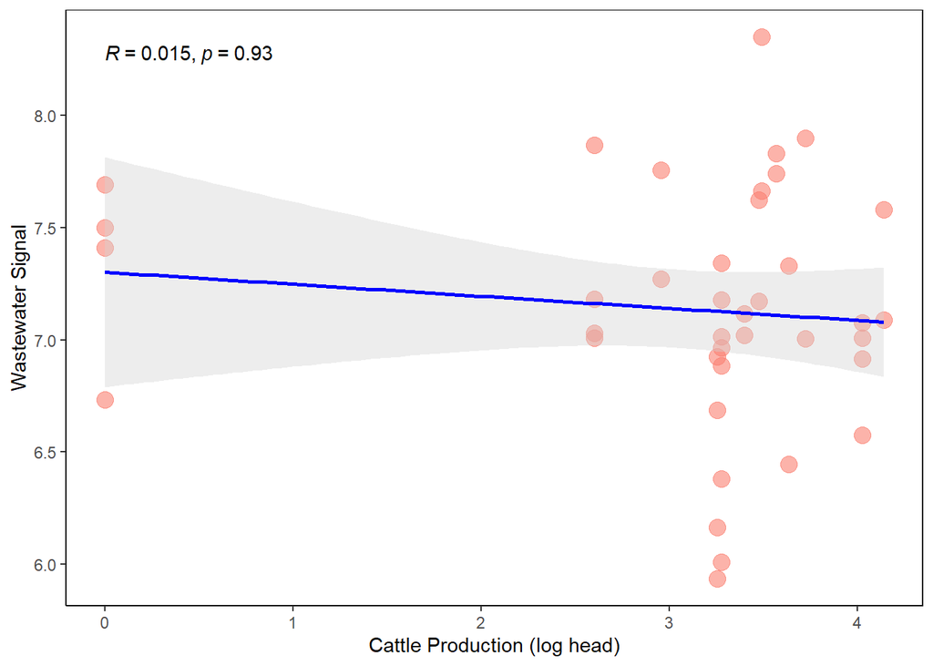

```r
AgriculturalProduction <- read_excel("Data/AgriculturalProduction_log_byCounty.xlsx")

#Extract data frame from phyloseq object
df <- data.frame(ps@otu_table)
colnames(df) <- data.frame(ps@tax_table)$CommonName
colnames(df) <- make.names(colnames(df), unique = TRUE)
metadata <- data.frame(ps@sam_data)
df$County <- metadata$County

#Signal of major agricultural animals
WastewaterSignals <- df[, c("County","Cattle.1","Chicken", "Turkey","Pig")]

# Add columns from AgriculturalProduction to df using match()
WastewaterSignals$Cattle_production <- AgriculturalProduction$Cattle_2021[match(WastewaterSignals$County, AgriculturalProduction$County)]
WastewaterSignals$Hog_production <- AgriculturalProduction$Hog_2021[match(WastewaterSignals$County, AgriculturalProduction$County)]
WastewaterSignals$Turkey_production <- AgriculturalProduction$Turkey_2021[match(WastewaterSignals$County, AgriculturalProduction$County)]
WastewaterSignals$Chicken_production <- AgriculturalProduction$Broiler_2021[match(WastewaterSignals$County, AgriculturalProduction$County)]

#Plot the scatter plots
scatter1 <- ggscatter(WastewaterSignals, x = "Cattle_production", y = "Cattle.1", size = 4, color = "#FA8072", alpha = 0.6, repel = FALSE,  font.label = c(9, "plain", "black"),
          add = "reg.line", add.params = list(color = "blue", fill = "lightgray"),
          conf.int = TRUE,
          cor.coef = TRUE, cor.method = "spearman",
          cor.coeff.args = list(method = "spearman", label.x.npc = "left", label.y.npc = "top"),
          xlab = "Cattle Production (log head)", ylab = "Wastewater Signal")+
  theme_classic() +
  theme(panel.border = element_rect(color = "black", fill = NA), # Adds an outer frame
        axis.line = element_line(color = "black"),               # Keeps axis lines
        panel.grid = element_blank())                            # Ensures no inner grid lines
scatter1
```

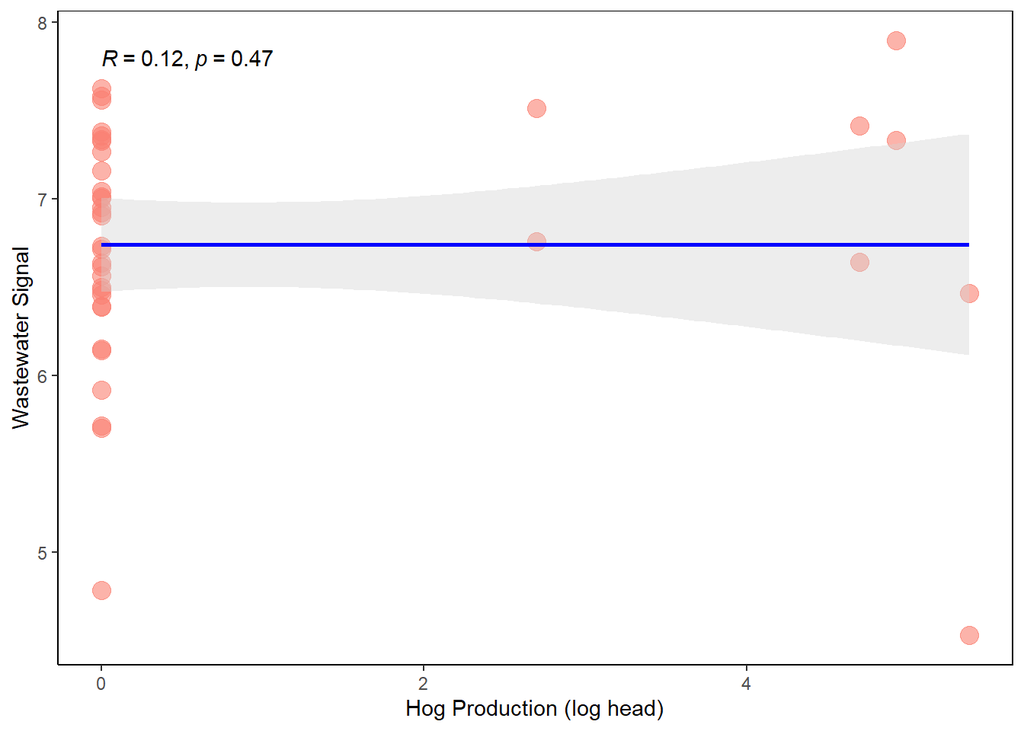

```r
scatter2 <- ggscatter(WastewaterSignals, x = "Hog_production", y = "Pig", size = 4, color = "#FA8072", alpha = 0.6, repel = FALSE,  font.label = c(9, "plain", "black"),
          add = "reg.line", add.params = list(color = "blue", fill = "lightgray"),
          conf.int = TRUE,
          cor.coef = TRUE, cor.method = "spearman",
          cor.coeff.args = list(method = "spearman", label.x.npc = "left", label.y.npc = "top"),
          xlab = "Hog Production (log head)", ylab = "Wastewater Signal")+
  theme_classic() +
  theme(panel.border = element_rect(color = "black", fill = NA), # Adds an outer frame
        axis.line = element_line(color = "black"),               # Keeps axis lines
        panel.grid = element_blank())                            # Ensures no inner grid lines
scatter2
```

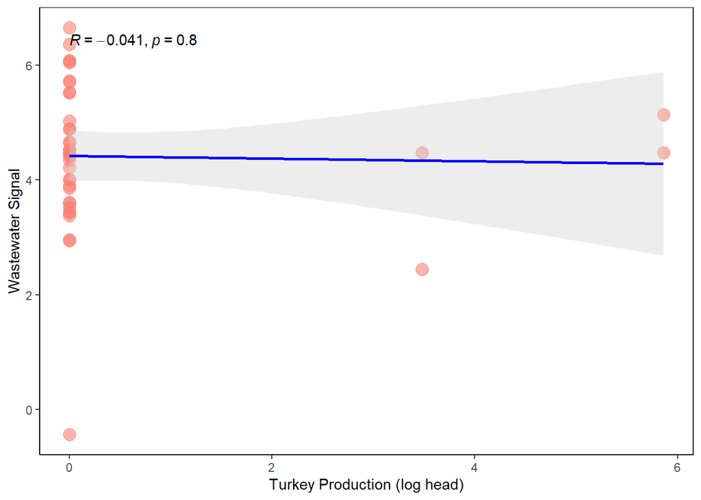

```r
scatter3 <- ggscatter(WastewaterSignals, x = "Turkey_production", y = "Turkey", size = 4, color = "#FA8072", alpha = 0.6, repel = FALSE,  font.label = c(9, "plain", "black"),
          add = "reg.line", add.params = list(color = "blue", fill = "lightgray"),
          conf.int = TRUE,
          cor.coef = TRUE, cor.method = "spearman",
          cor.coeff.args = list(method = "spearman", label.x.npc = "left", label.y.npc = "top"),
          xlab = "Turkey Production (log head)", ylab = "Wastewater Signal")+
  theme_classic() +
  theme(panel.border = element_rect(color = "black", fill = NA), # Adds an outer frame
        axis.line = element_line(color = "black"),               # Keeps axis lines
        panel.grid = element_blank())                            # Ensures no inner grid lines
scatter3
```

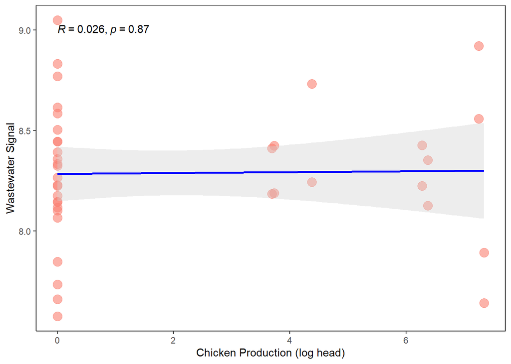

```r
scatter4 <- ggscatter(WastewaterSignals, x = "Chicken_production", y = "Chicken", size = 4, color = "#FA8072", alpha = 0.6, repel = FALSE,  font.label = c(9, "plain", "black"),
          add = "reg.line", add.params = list(color = "blue", fill = "lightgray"),
          conf.int = TRUE,
          cor.coef = TRUE, cor.method = "spearman",
          cor.coeff.args = list(method = "spearman", label.x.npc = "left", label.y.npc = "top"),
          xlab = "Chicken Production (log head)", ylab = "Wastewater Signal")+
  theme_classic() +
  theme(panel.border = element_rect(color = "black", fill = NA), # Adds an outer frame
        axis.line = element_line(color = "black"),               # Keeps axis lines
        panel.grid = element_blank())                            # Ensures no inner grid lines
scatter4
```

#Statistics: PERMANOVA (Supplementary Table 6 and 13)

```r
#temporal and spatial pattern of food with Charlotte, Beaufort, and Greenville data
ps <- NCWW_Seasonal_food_clr

##Extract data frame from phyloseq object
df <- data.frame(ps@otu_table)
metadata <- data.frame(ps@sam_data)

## Convert date to numeric variable
metadata$Month_Date <- as.Date(metadata$Date, format = "%m/%d")
metadata$Month_Date <- as.numeric(metadata$Month_Date)

permanova <- adonis2(df ~ County + Month_Date, data = metadata, method = "euclidean", by = "terms", permutations = 999)
print(permanova)
```

```
## Permutation test for adonis under reduced model
## Terms added sequentially (first to last)
## Permutation: free
## Number of permutations: 999
##
## adonis2(formula = df ~ County + Month_Date, data = metadata, permutations = 999, method = "euclidean", by = "terms")
##             Df SumOfSqs      R2      F Pr(>F)
## County       2     5718 0.09028 7.2441  0.001 ***
## Month_Date   1     1181 0.01865 2.9931  0.001 ***
## Residual   143    56440 0.89107
## Total      146    63340 1.00000
## ---
## Signif. codes:  0 '***' 0.001 '**' 0.01 '*' 0.05 '.' 0.1 ' ' 1
```

```r
#for Spatial fish consumption with 2021 data
ps <- NCWW_2021_fish_clr #spatial food consumption with 2021 data

##Extract data frame from phyloseq object
df <- data.frame(ps@otu_table)
metadata <- data.frame(ps@sam_data)
permanova <- adonis2(df ~ Coast_Inland + City_Town, data = metadata, method = "euclidean", by = "terms", permutations = 999)
print(permanova)
```

```
## Permutation test for adonis under reduced model
## Terms added sequentially (first to last)
## Permutation: free
## Number of permutations: 999
##
## adonis2(formula = df ~ Coast_Inland + City_Town, data = metadata, permutations = 999, method = "euclidean", by = "terms")
##              Df SumOfSqs      R2      F Pr(>F)
## Coast_Inland  1   108.90 0.06141 2.4647  0.001 ***
## City_Town     1    73.94 0.04170 1.6736  0.035 *
## Residual     36  1590.52 0.89690
## Total        38  1773.36 1.00000
## ---
## Signif. codes:  0 '***' 0.001 '**' 0.01 '*' 0.05 '.' 0.1 ' ' 1
```

#Plant-Animal-ratio, taxa richness, and Shannon Diversity (Fig 3b,d, Supplementary Fig 6a)

```r
#Using spatial samples from 2021, calculate Shannon diversity and tax richness (alpha-diversity index: observed)
NCWW_2021_int <- NCWW_2021
otu_table(NCWW_2021_int) <- round(otu_table(NCWW_2021_int))
alpha_diversity <- estimate_richness(NCWW_2021_int, measures=c("Observed", "Shannon"))

#Plant-animal-ratio (Use the statewide dataset)
ps_phylum <- tax_glom(NCWW_2021, taxrank = "phylum")
ps_phylum <- microbiome::transform(ps_phylum, "compositional")
otu_df <- as.data.frame(otu_table(ps_phylum))
tax_df <- as.data.frame(tax_table(ps_phylum))
colnames(otu_df) <- tax_df$phylum
otu_df$PAR <- otu_df$Streptophyta/otu_df$Chordata

#Combining two dataframes (otu_df and alpha_diversity) into one dataframe
df_diversity <- data.frame(otu_df, alpha_diversity)
df_diversity$Location <- ps_phylum@sam_data$Location

df_diversity
```

```
##              Chordata Streptophyta         PAR Observed   Shannon
## NCWW2021_1  0.9935951  0.006404889 0.006446176       38 1.2489377
## NCWW2021_2  0.7205201  0.279479877 0.387886289       55 2.5513290
## NCWW2021_3  0.8526256  0.147374366 0.172847684       54 1.6981545
## NCWW2021_4  0.7423395  0.257660453 0.347092451       56 1.8910934
## NCWW2021_5  0.7014567  0.298543311 0.425604767       53 2.0899490
## NCWW2021_6  0.8405890  0.159410954 0.189641960       56 1.8746280
## NCWW2021_7  0.9328469  0.067153111 0.071987281       55 1.5415219
## NCWW2021_8  0.5789724  0.421027562 0.727197936       58 2.4755815
## NCWW2021_9  0.8760782  0.123921829 0.141450652       67 1.4873398
## NCWW2021_10 0.8479913  0.152008715 0.179257403       35 1.0705699
## NCWW2021_11 0.9497069  0.050293094 0.052956437       54 1.5227668
## NCWW2021_12 0.9211240  0.078876046 0.085630220       58 1.7639989
## NCWW2021_13 0.6468167  0.353183300 0.546033057       57 2.5472121
## NCWW2021_14 0.1665762  0.833423829 5.003259615       57 3.4995578
## NCWW2021_15 0.7722701  0.227729936 0.294883806       58 2.2155826
## NCWW2021_16 0.7333575  0.266642465 0.363591362       67 2.5351209
## NCWW2021_17 0.9813143  0.018685674 0.019041477       47 1.0957019
## NCWW2021_18 0.9057404  0.094259601 0.104069114       52 1.5604625
## NCWW2021_19 0.7179766  0.282023419 0.392803089       70 2.2663891
## NCWW2021_20 0.6644330  0.335567016 0.505042682       69 2.2778246
## NCWW2021_21 0.8737015  0.126298496 0.144555658       40 1.4471183
## NCWW2021_22 0.8438573  0.156142705 0.185034490       49 2.0050163
## NCWW2021_23 0.8281959  0.171804096 0.207443789       72 1.7021120
## NCWW2021_24 0.9092813  0.090718652 0.099769617       68 1.6781299
## NCWW2021_25 0.7389710  0.261028994 0.353233066       56 2.1567937
## NCWW2021_26 0.8483832  0.151616811 0.178712654       56 1.7045093
## NCWW2021_27 0.8984503  0.101549714 0.113027638       63 1.2789418
## NCWW2021_28 0.9138613  0.086138734 0.094257999       64 1.5991115
## NCWW2021_29 0.7496432  0.250356778 0.333967907       66 2.2730776
## NCWW2021_30 0.4019345  0.598065456 1.487967293       72 3.1887005
## NCWW2021_31 0.2811711  0.718828907 2.556553378       61 3.1446227
## NCWW2021_32 0.6965656  0.303434390 0.435614944       66 1.8769508
## NCWW2021_33 0.9008535  0.099146527 0.110058439       65 0.8644211
## NCWW2021_34 0.9212143  0.078785654 0.085523695       53 1.6695968
## NCWW2021_35 0.8306102  0.169389829 0.203934210       52 1.8435005
## NCWW2021_36 0.9161850  0.083814987 0.091482600       51 1.5767305
## NCWW2021_37 0.8799542  0.120045781 0.136422757       55 1.8725473
## NCWW2021_38 0.6099814  0.390018621 0.639394308       49 2.2527006
## NCWW2021_39 0.8717150  0.128285036 0.147163971       60 1.7026546
```

[output cut: 25 more lines]

```
## NCWW2021_25  Roanoke Rapids
## NCWW2021_26  Roanoke Rapids
## NCWW2021_27     Charlotte 2
## NCWW2021_28     Charlotte 2
## NCWW2021_29     Charlotte 2
## NCWW2021_30          Durham
## NCWW2021_31          Durham
## NCWW2021_32          Wilson
## NCWW2021_33          Wilson
## NCWW2021_34 Wilmington City
## NCWW2021_35 Wilmington City
## NCWW2021_36  Hanover County
## NCWW2021_37  Hanover County
## NCWW2021_38   Winston Salem
## NCWW2021_39   Winston Salem
```

#Statistics: One-way ANOVA

```r
#Test data distribution
shapiro.test(df_diversity$Shannon)
```

```
##
##  Shapiro-Wilk normality test
##
## data:  df_diversity$Shannon
## W = 0.9512, p-value = 0.09021
```

```r
shapiro.test(df_diversity$Observed)
```

```
##
##  Shapiro-Wilk normality test
##
## data:  df_diversity$Observed
## W = 0.95774, p-value = 0.1498
```

```r
shapiro.test(df_diversity$PAR)
```

```
##
##  Shapiro-Wilk normality test
##
## data:  df_diversity$PAR
## W = 0.442, p-value = 5.255e-11
```

```r
# ANOVA for normal distribution
anova_result <- aov(Shannon ~ Location, data = df_diversity)
summary(anova_result)
```

```
##             Df Sum Sq Mean Sq F value Pr(>F)
## Location    18  8.981  0.4989    2.81 0.0139 *
## Residuals   20  3.552  0.1776
## ---
## Signif. codes:  0 '***' 0.001 '**' 0.01 '*' 0.05 '.' 0.1 ' ' 1
```

```r
##Significant ANOVA result followed by Tukey's HSD Post-hoc test
TukeyHSD(anova_result)
```

```
##   Tukey multiple comparisons of means
##     95% family-wise confidence level
##
## Fit: aov(formula = Shannon ~ Location, data = df_diversity)
##
## $Location
##                                        diff         lwr          upr     p adj
## Beaufort-Asheville              0.105509407 -1.58199063  1.793009443 1.0000000
## Carrboro-Asheville             -0.104502998 -1.79200303  1.582997038 1.0000000
## Charlotte 1-Asheville           1.228761030 -0.45873901  2.916261065 0.3403279
## Charlotte 2-Asheville          -0.077580301 -1.61805003  1.462889424 1.0000000
## Charlotte 3-Asheville           0.580727821 -1.10677221  2.268227856 0.9930500
## Durham-Asheville                1.372037687 -0.31546235  3.059537722 0.1998281
## Fayetteville-Asheville          0.187664554 -1.49983548  1.875164589 1.0000000
## Greensboro-Asheville            0.213927773 -1.47357226  1.901427808 1.0000000
## Greenville-Asheville           -0.515669114 -2.20316915  1.171830921 0.9980733
## Hanover County-Asheville       -0.069985005 -1.75748504  1.617515030 1.0000000
## Laurinburg-Asheville           -0.151241061 -1.83874110  1.536258974 1.0000000
## Marion-Asheville               -0.466541718 -2.15404175  1.220958317 0.9994106
## Newport-Asheville              -0.068556611 -1.75605665  1.618943425 1.0000000
## Raleigh-Asheville               0.477482948 -1.21001709  2.164982983 0.9992185
## Roanoke Rapids-Asheville        0.136027619 -1.55147242  1.823527655 1.0000000
## Wilmington City-Asheville      -0.038075270 -1.72557531  1.649424765 1.0000000
## Wilson-Asheville               -0.423937978 -2.11143801  1.263562058 0.9998248
## Winston Salem-Asheville         0.183053685 -1.50444635  1.870553720 1.0000000
## Carrboro-Beaufort              -0.210012405 -1.89751244  1.477487630 1.0000000
## Charlotte 1-Beaufort            1.123251622 -0.56424841  2.810751657 0.4758325
## Charlotte 2-Beaufort           -0.183089709 -1.72355943  1.357380017 1.0000000
## Charlotte 3-Beaufort            0.475218413 -1.21228162  2.162718449 0.9992621
## Durham-Beaufort                 1.266528280 -0.42097176  2.954028315 0.2980987
## Fayetteville-Beaufort           0.082155147 -1.60534489  1.769655182 1.0000000
## Greensboro-Beaufort             0.108418365 -1.57908167  1.795918401 1.0000000
## Greenville-Beaufort            -0.621178521 -2.30867856  1.066321514 0.9865079
## Hanover County-Beaufort        -0.175494413 -1.86299445  1.512005622 1.0000000
## Laurinburg-Beaufort            -0.256750468 -1.94425050  1.430749567 0.9999999
## Marion-Beaufort                -0.572051125 -2.25955116  1.115448910 0.9940465
## Newport-Beaufort               -0.174066018 -1.86156605  1.513434017 1.0000000
## Raleigh-Beaufort                0.371973541 -1.31552649  2.059473576 0.9999702
## Roanoke Rapids-Beaufort         0.030518212 -1.65698182  1.718018247 1.0000000
## Wilmington City-Beaufort       -0.143584678 -1.83108471  1.543915358 1.0000000
```

[output cut: 123 more lines]

```
## Raleigh-Newport                 0.546039559 -1.14146048  2.233539594 0.9963633
## Roanoke Rapids-Newport          0.204584230 -1.48291581  1.892084265 1.0000000
## Wilmington City-Newport         0.030481340 -1.65701870  1.717981375 1.0000000
## Wilson-Newport                 -0.355381367 -2.04288140  1.332118668 0.9999843
## Winston Salem-Newport           0.251610296 -1.43588974  1.939110331 0.9999999
## Roanoke Rapids-Raleigh         -0.341455329 -2.02895536  1.346044707 0.9999912
## Wilmington City-Raleigh        -0.515558218 -2.20305825  1.171941817 0.9980780
## Wilson-Raleigh                 -0.901420926 -2.58892096  0.786079109 0.7870788
## Winston Salem-Raleigh          -0.294429263 -1.98192930  1.393070772 0.9999990
## Wilmington City-Roanoke Rapids -0.174102890 -1.86160292  1.513397145 1.0000000
## Wilson-Roanoke Rapids          -0.559965597 -2.24746563  1.127534438 0.9952387
## Winston Salem-Roanoke Rapids    0.047026066 -1.64047397  1.734526101 1.0000000
## Wilson-Wilmington City         -0.385862707 -2.07336274  1.301637328 0.9999504
## Winston Salem-Wilmington City   0.221128955 -1.46637108  1.908628991 1.0000000
## Winston Salem-Wilson            0.606991663 -1.08050837  2.294491698 0.9891963
```

```r
# ANOVA for normal distribution
anova_result <- aov(Observed ~ Location, data = df_diversity)
summary(anova_result)
```

```
##             Df Sum Sq Mean Sq F value Pr(>F)
## Location    18 2021.7  112.32   2.463  0.027 *
## Residuals   20  912.2   45.61
## ---
## Signif. codes:  0 '***' 0.001 '**' 0.01 '*' 0.05 '.' 0.1 ' ' 1
```

```r
##Significant ANOVA result followed by Tukey's HSD Post-hoc test
TukeyHSD(anova_result)
```

```
##   Tukey multiple comparisons of means
##     95% family-wise confidence level
##
## Fit: aov(formula = Observed ~ Location, data = df_diversity)
##
## $Location
##                                         diff        lwr       upr     p adj
## Beaufort-Asheville             -8.500000e+00 -35.543785 18.543785 0.9973562
## Carrboro-Asheville              1.500000e+01 -12.043785 42.043785 0.7422819
## Charlotte 1-Asheville           2.000000e+00 -25.043785 29.043785 1.0000000
## Charlotte 2-Asheville           9.333333e+00 -15.354152 34.020818 0.9826844
## Charlotte 3-Asheville           7.500000e+00 -19.543785 34.543785 0.9993878
## Durham-Asheville                1.150000e+01 -15.543785 38.543785 0.9526366
## Fayetteville-Asheville         -5.000000e-01 -27.543785 26.543785 1.0000000
## Greensboro-Asheville            1.500000e+00 -25.543785 28.543785 1.0000000
## Greenville-Asheville           -4.000000e+00 -31.043785 23.043785 0.9999999
## Hanover County-Asheville       -2.000000e+00 -29.043785 25.043785 1.0000000
## Laurinburg-Asheville            1.000000e+00 -26.043785 28.043785 1.0000000
## Marion-Asheville               -5.500000e+00 -32.543785 21.543785 0.9999905
## Newport-Asheville              -1.050000e+01 -37.543785 16.543785 0.9779601
## Raleigh-Asheville               1.450000e+01 -12.543785 41.543785 0.7828644
## Roanoke Rapids-Asheville        1.000000e+00 -26.043785 28.043785 1.0000000
## Wilmington City-Asheville      -2.500000e+00 -29.543785 24.543785 1.0000000
## Wilson-Asheville                1.050000e+01 -16.543785 37.543785 0.9779601
## Winston Salem-Asheville        -5.000000e-01 -27.543785 26.543785 1.0000000
## Carrboro-Beaufort               2.350000e+01  -3.543785 50.543785 0.1354151
## Charlotte 1-Beaufort            1.050000e+01 -16.543785 37.543785 0.9779601
## Charlotte 2-Beaufort            1.783333e+01  -6.854152 42.520818 0.3518409
## Charlotte 3-Beaufort            1.600000e+01 -11.043785 43.043785 0.6551842
## Durham-Beaufort                 2.000000e+01  -7.043785 47.043785 0.3183868
## Fayetteville-Beaufort           8.000000e+00 -19.043785 35.043785 0.9986749
## Greensboro-Beaufort             1.000000e+01 -17.043785 37.043785 0.9859187
## Greenville-Beaufort             4.500000e+00 -22.543785 31.543785 0.9999995
## Hanover County-Beaufort         6.500000e+00 -20.543785 33.543785 0.9999024
## Laurinburg-Beaufort             9.500000e+00 -17.543785 36.543785 0.9914469
## Marion-Beaufort                 3.000000e+00 -24.043785 30.043785 1.0000000
## Newport-Beaufort               -2.000000e+00 -29.043785 25.043785 1.0000000
## Raleigh-Beaufort                2.300000e+01  -4.043785 50.043785 0.1544591
## Roanoke Rapids-Beaufort         9.500000e+00 -17.543785 36.543785 0.9914469
## Wilmington City-Beaufort        6.000000e+00 -21.043785 33.043785 0.9999673
```

[output cut: 123 more lines]

```
## Raleigh-Newport                 2.500000e+01  -2.043785 52.043785 0.0899114
## Roanoke Rapids-Newport          1.150000e+01 -15.543785 38.543785 0.9526366
## Wilmington City-Newport         8.000000e+00 -19.043785 35.043785 0.9986749
## Wilson-Newport                  2.100000e+01  -6.043785 48.043785 0.2537260
## Winston Salem-Newport           1.000000e+01 -17.043785 37.043785 0.9859187
## Roanoke Rapids-Raleigh         -1.350000e+01 -40.543785 13.543785 0.8549875
## Wilmington City-Raleigh        -1.700000e+01 -44.043785 10.043785 0.5647069
## Wilson-Raleigh                 -4.000000e+00 -31.043785 23.043785 0.9999999
## Winston Salem-Raleigh          -1.500000e+01 -42.043785 12.043785 0.7422819
## Wilmington City-Roanoke Rapids -3.500000e+00 -30.543785 23.543785 1.0000000
## Wilson-Roanoke Rapids           9.500000e+00 -17.543785 36.543785 0.9914469
## Winston Salem-Roanoke Rapids   -1.500000e+00 -28.543785 25.543785 1.0000000
## Wilson-Wilmington City          1.300000e+01 -14.043785 40.043785 0.8855612
## Winston Salem-Wilmington City   2.000000e+00 -25.043785 29.043785 1.0000000
## Winston Salem-Wilson           -1.100000e+01 -38.043785 16.043785 0.9670289
```

```r
# Kruskal-Wallis for not normal distribution
kruskal.test(PAR ~ Location, data = df_diversity)  #No significant differences in Plant-Animal-Ratio between locations
```

```
##
##  Kruskal-Wallis rank sum test
##
## data:  PAR by Location
## Kruskal-Wallis chi-squared = 23.065, df = 18, p-value = 0.1881
```

# Compare wastewater plant with stool samples (Fig 1c)

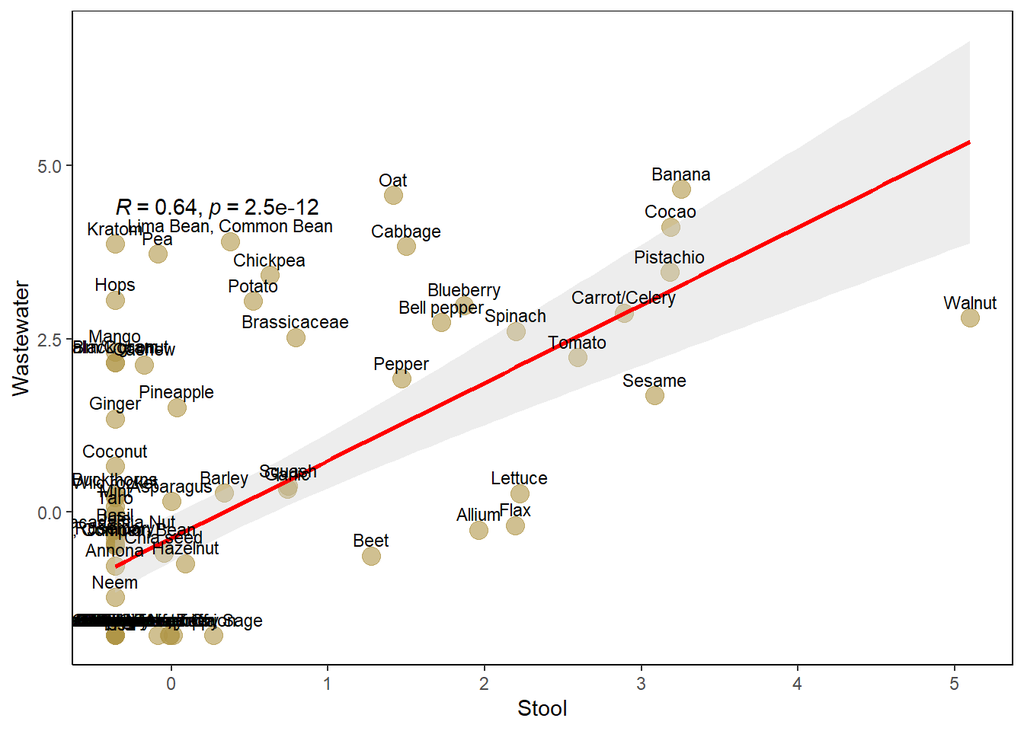

```r
#Read in the organized datafile "Durham_WWStoolJune"
Durham_WWStoolJune <-read.csv("Data/Durham_WWStoolJune.csv", header = TRUE)

#Create scatter plot
scatter <- ggscatter(Durham_WWStoolJune, x = "Stool_mean", y = "WW_mean", size = 4, color = "#B09647", alpha = 0.6, label = "label", repel = FALSE,  font.label = c(9, "plain", "black"),
          add = "reg.line", add.params = list(color = "red", fill = "lightgray"),
          conf.int = TRUE,
          cor.coef = TRUE, cor.method = "spearman",
          cor.coeff.args = list(label.x.npc = "left", label.y.npc = "top", method = "spearman"),
          xlab = "Stool", ylab = "Wastewater")+
  theme_classic() +
  theme(panel.border = element_rect(color = "black", fill = NA), # Adds an outer frame
        axis.line = element_line(color = "black"),               # Keeps axis lines
        panel.grid = element_blank())                            # Ensures no inner grid lines
scatter
```

#Ordination plot with ggplot (Fig 2a and S. Fig 2 and 3)

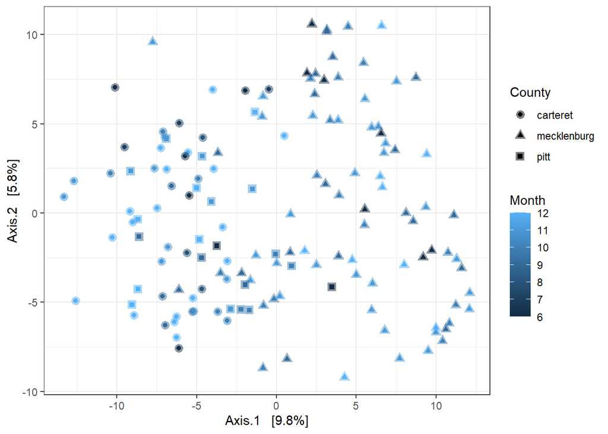

```r
# Assuming 'ord' contains the ordination results
# and 'NCWW_SeasonalFood_clr' contains the sample data
ps <- NCWW_Seasonal_food_clr
ord <- ordinate(ps, method="MDS", distance = "euclidean")

p_ord <- plot_ordination(NCWW_Seasonal_food_clr, ord, color = "Month", shape = "County", axes = c(1, 2)) +
 theme(text = element_text(size = 16))+
  geom_point(size = 3, alpha = 0.5) +
  theme_bw()
p_ord
```

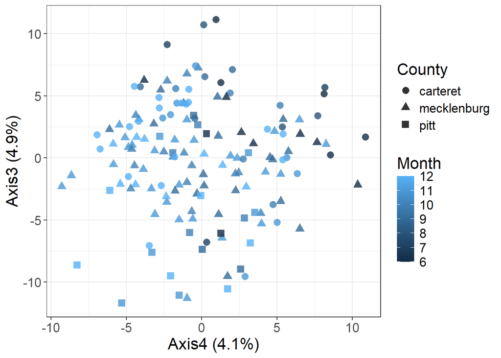

```r
# First, extract ordination scores
scores_df <- as.data.frame(ord$vectors)  # Adjust based on your specific ordination object structure

# Merge scores with metadata
metadata <- as.data.frame(ps@sam_data)
combined_df <- cbind(scores_df, metadata)


# Define your custom transparency levels
alpha_values <- c("NCWW022621" = 0.3, "NCWW121720" = 0.3, "NCWW2021" = 0.9)

# Create the plot with color by Month
p_ord <- ggplot(combined_df, aes(x = Axis.4, y = Axis.3, color = Month, shape = County)) +
  geom_point(size = 3, alpha = 0.8) +
  #scale_color_manual(values = c("carteret" = "red", "mecklenburg" = "blue", "pitt" = "green")) +
  scale_alpha_manual(values = alpha_values) +
  theme_bw() +
  theme(text = element_text(size = 16)) +
  labs(y = "Axis3 (4.9%)", x = "Axis4 (4.1%)") +
  guides(alpha = FALSE)  # Optionally remove the alpha legend
p_ord
```

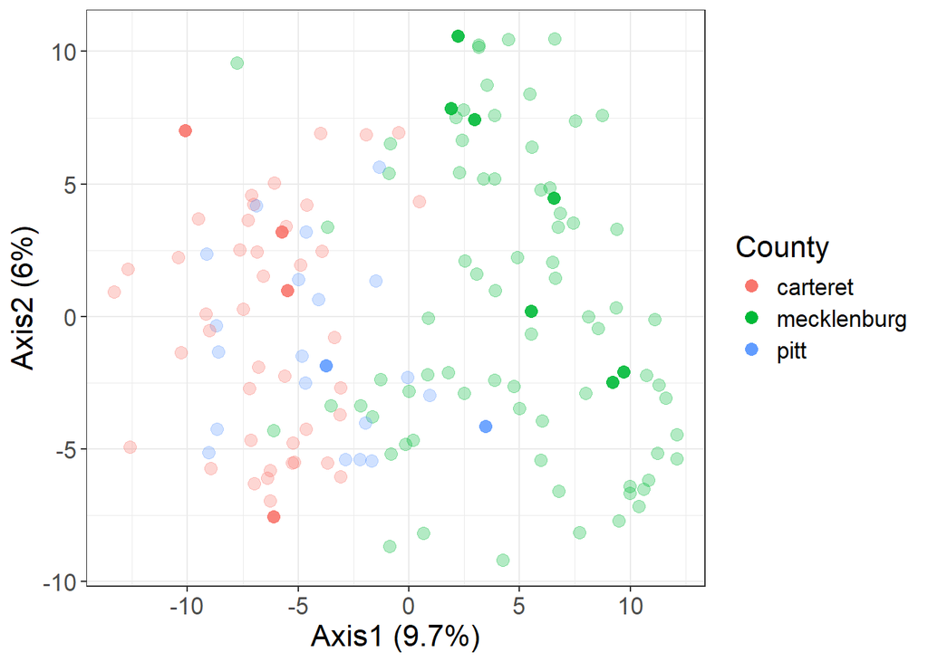

```r
# Create the plot with color by County
p_ord <- ggplot(combined_df, aes(x = Axis.1, y = Axis.2, color = County, alpha = Plate)) +
  geom_point(size = 3) +
  scale_alpha_manual(values = alpha_values) +
  theme_bw() +
  theme(text = element_text(size = 16)) +
  labs(x = "Axis1 (9.7%)", y = "Axis2 (6%)") +
  guides(alpha = FALSE)  # Optionally remove the alpha legend

p_ord
```

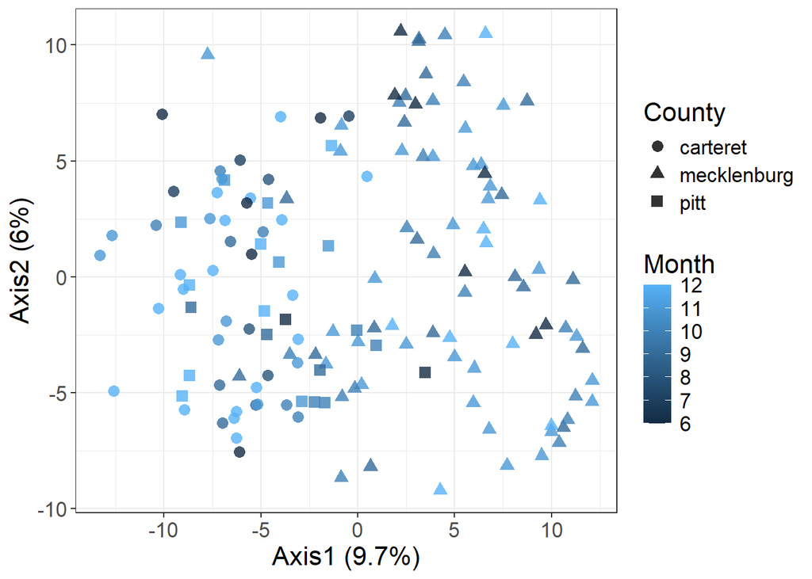

```r
p_ord <- ggplot(combined_df, aes(x = Axis.1, y = Axis.2, color = Month, shape = County)) +
  geom_point(size = 3, alpha = 0.8) +
  scale_alpha_manual(values = alpha_values) +
  theme_bw() +
  theme(text = element_text(size = 16)) +
  labs(x = "Axis1 (9.7%)", y = "Axis2 (6%)") +
  guides(alpha = FALSE)  # Optionally remove the alpha legend

p_ord
```

```r
#Axis and Time correlation
combined_df$time <- as.Date(combined_df$Date,format = "%m/%d")
combined_df$time <- as.numeric(combined_df$time)
cor.test(combined_df$Axis.1, combined_df$time, method = "spearman")
```

```
##
##  Spearman's rank correlation rho
##
## data:  combined_df$Axis.1 and combined_df$time
## S = 607427, p-value = 0.07482
## alternative hypothesis: true rho is not equal to 0
## sample estimates:
##        rho
## -0.1473959
```

```r
cor.test(combined_df$Axis.2, combined_df$time, method = "spearman")
```

```
##
##  Spearman's rank correlation rho
##
## data:  combined_df$Axis.2 and combined_df$time
## S = 595604, p-value = 0.1312
## alternative hypothesis: true rho is not equal to 0
## sample estimates:
##        rho
## -0.1250631
```

```r
cor.test(combined_df$Axis.3, combined_df$time, method = "spearman")
```

```
##
##  Spearman's rank correlation rho
##
## data:  combined_df$Axis.3 and combined_df$time
## S = 639215, p-value = 0.0117
## alternative hypothesis: true rho is not equal to 0
## sample estimates:
##        rho
## -0.2074413
```

```r
cor.test(combined_df$Axis.4, combined_df$time, method = "spearman")
```

```
##
##  Spearman's rank correlation rho
##
## data:  combined_df$Axis.4 and combined_df$time
## S = 760901, p-value = 3.057e-08
## alternative hypothesis: true rho is not equal to 0
## sample estimates:
##        rho
## -0.4373003
```

```r
cor.test(combined_df$Axis.5, combined_df$time, method = "spearman")
```

```
##
##  Spearman's rank correlation rho
##
## data:  combined_df$Axis.5 and combined_df$time
## S = 536521, p-value = 0.8715
## alternative hypothesis: true rho is not equal to 0
## sample estimates:
##         rho
## -0.01345787
```

#Seasonal fish heatmap (Fig 2c)

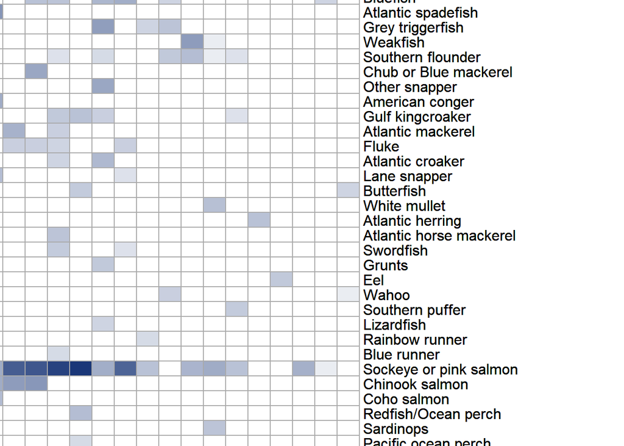

```r
# Read in the organized datafile "Heatmap_SeasonalFish_byMonth"
Heatmap_SeasonalFish_byMonth <- read.csv("Data/Heatmap_SeasonalFish_byMonth.csv", header = TRUE, row.names = 1)

#Make the heatmap dataframe
df_SUM <- Heatmap_SeasonalFish_byMonth[,6:22]
df_SUM <- data.frame(df_SUM)
row.names(df_SUM)<-row.names(Heatmap_SeasonalFish_byMonth)

# Get taxagroup from a df
taxagroup <- Heatmap_SeasonalFish_byMonth[,1:2]
taxagroup <- data.frame(taxagroup)
row.names(taxagroup) <- row.names(Heatmap_SeasonalFish_byMonth)

# make log transformed table if not
df_SUM_log <- log(df_SUM + 1)

#Heatmap
library(pheatmap)
heatmap_abundance <- pheatmap(df_SUM_log, color = colorRampPalette(c("white", "#012169"))(100), labels_row = NULL, cluster_cols = FALSE, cluster_rows = FALSE, annotation_row = taxagroup, cellwidth = 18, cellheight = 12, border_color = "darkgray", fontsize = 12)

heatmap_abundance
```

#PCA: Demographic factors (Fig 3a)

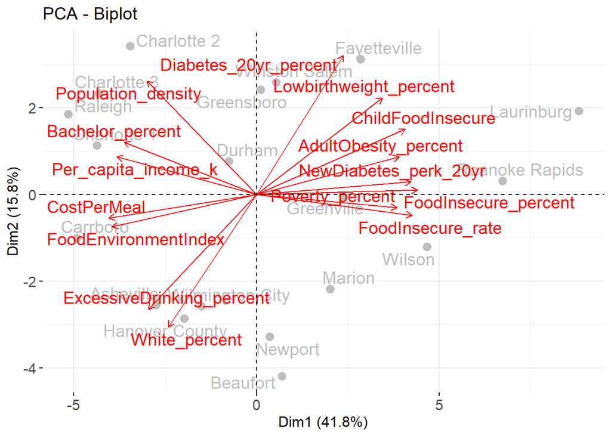

```r
#Demographic matrix
metadata <- data.frame(NCWW_2021@sam_data)
X <- metadata[, 27:63]
X_scaled <- scale(X, center = TRUE, scale = TRUE)

library(textshape)
# PCA by prcomp() on count table
pca_df <- data.frame(X_scaled)
pca_df$Location <- metadata$Location

# from combined_df, calculate the average read counts by Location
pca_df <- pca_df %>%
  group_by(Location) %>%
  summarise(across(
    .cols = where(is.numeric),  # Selects all numeric columns
    .fns = ~ mean(.x, na.rm = TRUE)  # Calculate the mean, remove NA values
  )) %>%
  ungroup() %>%  # Remove grouping
  column_to_rownames("Location")  # Convert 'Location' column to row names

# PCA
res.pca <- prcomp(pca_df, center = TRUE, scale. = TRUE)
pc_loadings <- res.pca$x

library(factoextra)
plot_pca <- fviz_pca_biplot(res.pca, repel = TRUE,              # label = "var" only display the labels for var.
                col.var = "red", # Variables color
                col.ind = "grey",  # Individuals color
                select.var = list(contrib = 15), pointsize = 3, labelsize = 5,
                ggtheme = theme_minimal()) + theme(text = element_text(size = 12),
        axis.title = element_text(size = 12),
        axis.text = element_text(size = 12))
plot_pca
```

```r
Demographics_scaled <- as.matrix(pca_df)
```

#PCA:Plant (Fig 4a,b,c)

```r
#Use following subset
NCWW_2021_plant_clr
```

```
## phyloseq-class experiment-level object
## otu_table()   OTU Table:         [ 136 taxa and 39 samples ]
## sample_data() Sample Data:       [ 39 samples by 64 sample variables ]
## tax_table()   Taxonomy Table:    [ 136 taxa by 15 taxonomic ranks ]
```

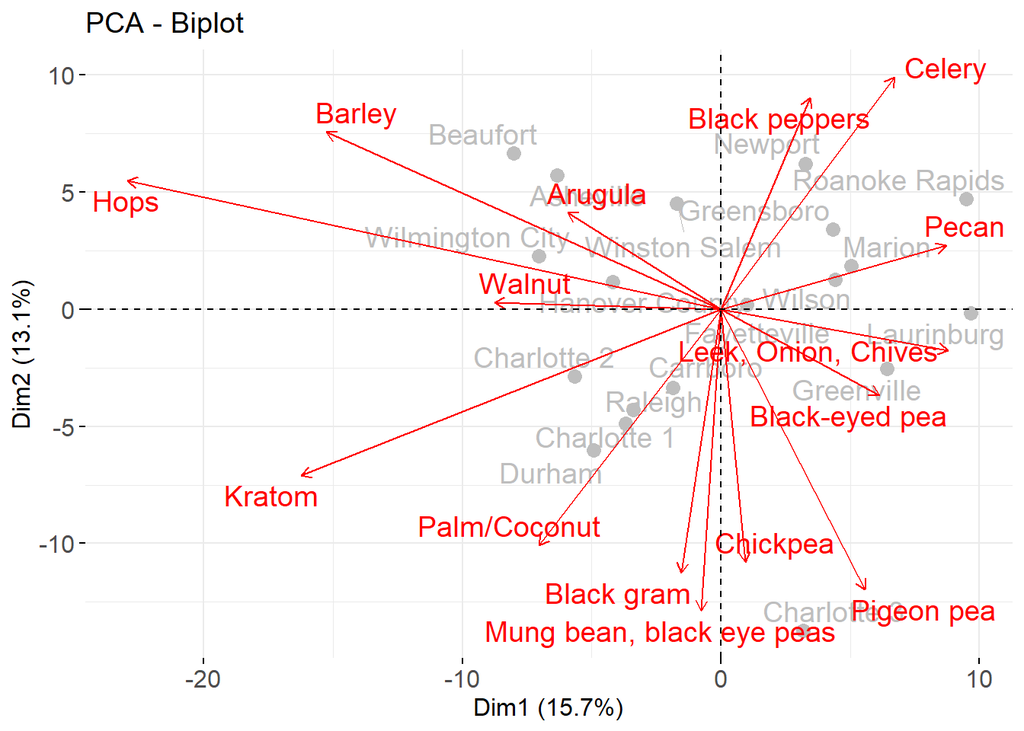

```r
#PCA from prcomp()
df <- data.frame(NCWW_2021_plant_clr@otu_table) #count table
colnames(df) <- data.frame(NCWW_2021_plant_clr@tax_table)$CommonName

unique_names <- make.unique(names(df), sep = ".")
df_unique <- df
names(df_unique) <- unique_names

# PCA by prcomp() on count table
pca_df <- df_unique
metadata <- data.frame(NCWW_2021_plant_clr@sam_data)
pca_df$Location <- metadata$Location

# from combined_df, calculate the average read counts by Location
pca_df <- pca_df %>%
  group_by(Location) %>%
  summarise(across(
    .cols = where(is.numeric),  # Selects all numeric columns
    .fns = ~ mean(.x, na.rm = TRUE)  # Calculate the mean, remove NA values
  )) %>%
  ungroup() %>%  # Remove grouping
  column_to_rownames("Location")  # Convert 'Location' column to row names

res.pca <- prcomp(pca_df)
pc_loadings_plant <- merge(res.pca$x, Demographics_scaled, by.x = 0, by.y = 0)

library(factoextra)
plot_pca <- fviz_pca_biplot(res.pca, repel = TRUE,              # label = "var" only display the labels for var.
                col.var = "red", # Variables color
                col.ind = "grey",  # Individuals color
                select.var = list(contrib = 15), pointsize = 3, labelsize = 5,
                ggtheme = theme_minimal()) + theme(text = element_text(size = 12),
        axis.title = element_text(size = 12),
        axis.text = element_text(size = 12))
plot_pca
```

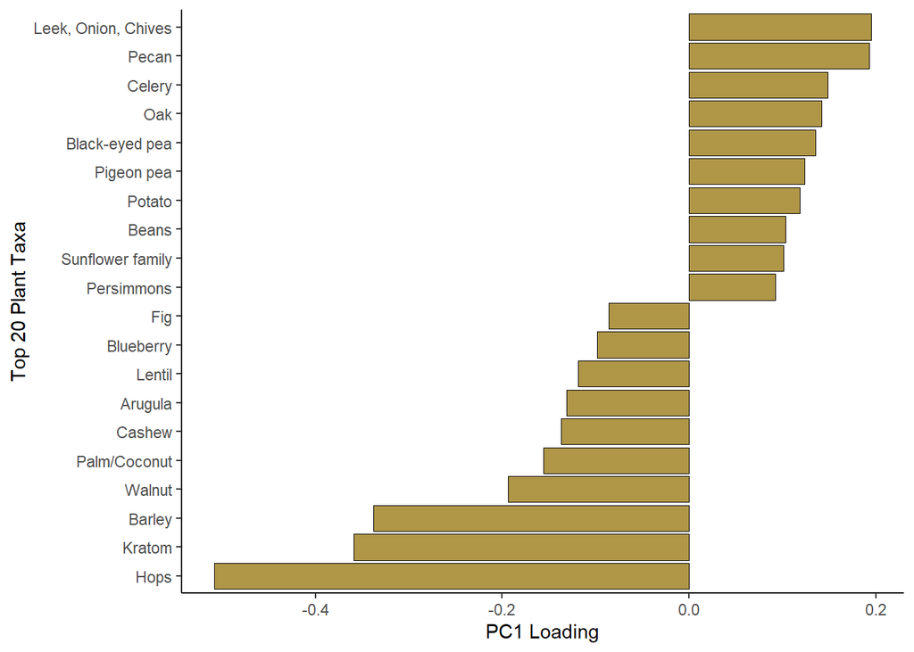

```r
# get PC rotations (contributions) from PCA object
pca.contri <- data.frame(res.pca$rotation) %>%
  rownames_to_column(var = "PlantType")

# Filter for the top 10 factors with the highest absolute Y_ratio.1.comps
top_factors <- pca.contri %>%
  mutate(abs_value = abs(PC1)) %>%  # Create a column for the absolute values
  arrange(desc(abs_value)) %>%  # Sort by absolute value in descending order
  slice(1:20)  # Select the top 10 rows

# Plot PC1 components
PC1_loading <- ggplot(top_factors, aes(x = reorder(PlantType, PC1), y = PC1, fill = PlantType)) +
  geom_bar(stat = "identity", fill = "#B09647",linewidth = 0.2, color = "black") +  # Use geom_bar and set stat to "identity" to use actual y values
  labs(x = "Top 20 Plant Taxa", y = "PC1 Loading") +  # Label the chart and axes
  theme_classic() +
  theme(text = element_text(color = "black"))+
  coord_flip()

PC1_loading
```

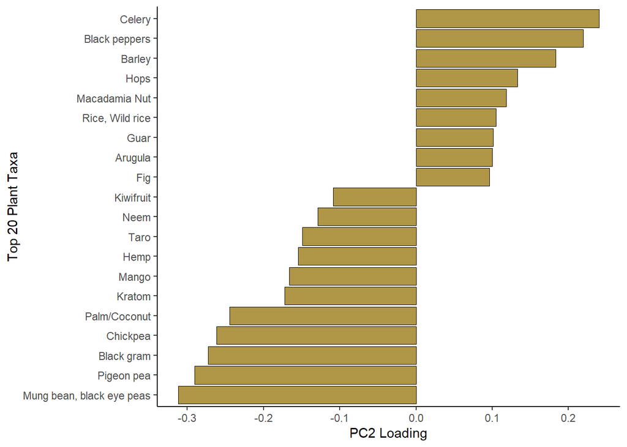

```r
# Filter for the top 10 factors with the highest absolute Y_ratio.1.comps
top_factors <- pca.contri %>%
  mutate(abs_value = abs(PC2)) %>%  # Create a column for the absolute values
  arrange(desc(abs_value)) %>%  # Sort by absolute value in descending order
  slice(1:20)  # Select the top 10 rows

PC2_loading <- ggplot(top_factors, aes(x = reorder(PlantType, PC2), y = PC2, fill = PlantType)) +
  geom_bar(stat = "identity",fill = "#B09647",linewidth = 0.2, color = "black") +  # Use geom_bar and set stat to "identity" to use actual y values
  labs(x = "Top 20 Plant Taxa", y = "PC2 Loading") +  # Label the chart and axes
  theme_classic() +
  theme(text = element_text(color = "black"))+
  coord_flip()

PC2_loading
```

#PCA: fish (Fig 5a,b,c)

```r
#Use following subset
NCWW_2021_fish_clr
```

```
## phyloseq-class experiment-level object
## otu_table()   OTU Table:         [ 54 taxa and 39 samples ]
## sample_data() Sample Data:       [ 39 samples by 64 sample variables ]
## tax_table()   Taxonomy Table:    [ 54 taxa by 15 taxonomic ranks ]
## phy_tree()    Phylogenetic Tree: [ 54 tips and 53 internal nodes ]
```

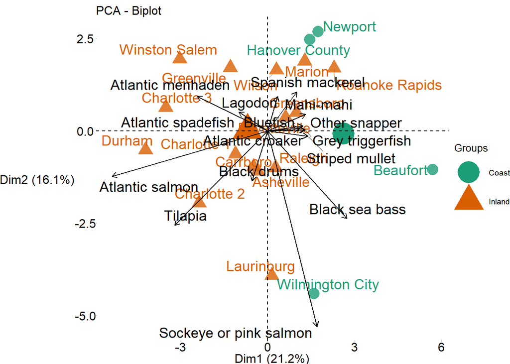

```r
#PCA from prcomp()
df <- data.frame(NCWW_2021_fish_clr@otu_table) #count table
colnames(df) <- data.frame(NCWW_2021_fish_clr@tax_table)$CommonName

unique_names <- make.unique(names(df), sep = ".")
df_unique <- df
names(df_unique) <- unique_names

# PCA by prcomp() on count table
pca_df <- df_unique
metadata <- data.frame(NCWW_2021_fish_clr@sam_data)
pca_df$Location <- metadata$Location

# from combined_df, calculate the average read counts by Location
pca_df <- pca_df %>%
  group_by(Location) %>%
  summarise(across(
    .cols = where(is.numeric),  # Selects all numeric columns
    .fns = ~ mean(.x, na.rm = TRUE)  # Calculate the mean, remove NA values
  )) %>%
  ungroup() %>%  # Remove grouping
  column_to_rownames("Location")  # Convert 'Location' column to row names

res.pca <- prcomp(pca_df)
pc_loadings_fish <- merge(res.pca$x, Demographics_scaled, by.x = 0, by.y = 0)

library(factoextra)

df_locations <- data.frame(
  Location = row.names(pca_df),
  Coast_Inland = metadata$Coast_Inland[match(row.names(pca_df), metadata$Location)]
)

plot_pca <- fviz_pca_biplot(res.pca, repel = TRUE,
                habillage = df_locations$Coast_Inland,
                #label = "var",
                col.var = "black", # Variables color
                col.ind = "gray",  # Individuals color
                alpha.ind = 0.8,
                #invisible = "var", # choose to not show var or ind or none
                select.var = list(contrib = 15), pointsize = 5, labelsize = 5,
                ggtheme = theme_void()) + theme(panel.grid.major = element_blank(),  # Remove major grid lines
    panel.grid.minor = element_blank(),  # Remove minor grid lines,
    text = element_text(size = 10),
        axis.title = element_text(size = 12),
        axis.text = element_text(size = 12)) + scale_color_brewer(palette="Dark2")
plot_pca
```

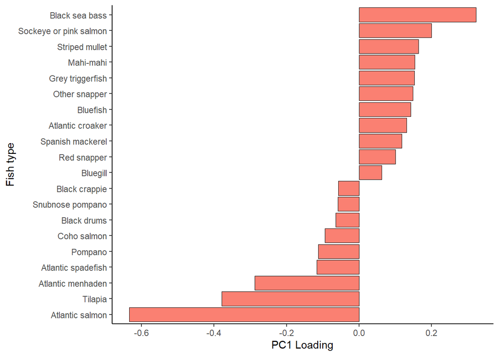

```r
# get PC rotations (contributions) from PCA object
pca.contri <- data.frame(res.pca$rotation) %>%
  rownames_to_column(var = "Fish")

# Filter for the top 20 factors with the highest absolute values
top_factors <- pca.contri %>%
  mutate(abs_value = abs(PC1)) %>%  # Create a column for the absolute values
  arrange(desc(abs_value)) %>%  # Sort by absolute value in descending order
  slice(1:20)  # Select the top 20 rows

# Plot PC1 components
PC1_loading <- ggplot(top_factors, aes(x = reorder(Fish, PC1), y = PC1, fill = Fish)) +
  geom_bar(stat = "identity", fill = "#FA8072", color = "black", linewidth = 0.2) +  # Use geom_bar and set stat to "identity" to use actual y values
  labs(x = "Fish type", y = "PC1 Loading") +  # Label the chart and axes
  theme_classic() +
  theme(text = element_text(color = "black"))+
  coord_flip()

PC1_loading
```

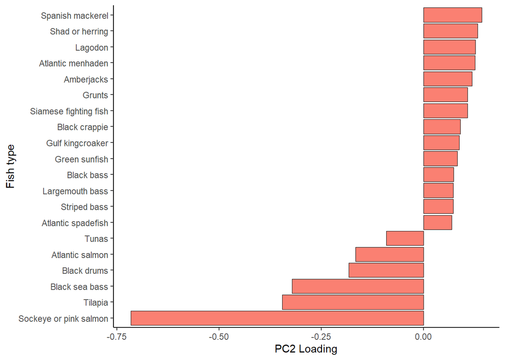

```r
# Filter for the top 20 factors with the highest absolute values
top_factors <- pca.contri %>%
  mutate(abs_value = abs(PC2)) %>%  # Create a column for the absolute values
  arrange(desc(abs_value)) %>%  # Sort by absolute value in descending order
  slice(1:20)  # Select the top 20 rows

PC2_loading <- ggplot(top_factors, aes(x = reorder(Fish, PC2), y = PC2, fill = Fish)) +
  geom_bar(stat = "identity", fill = "#FA8072", color = "black", linewidth = 0.2) +  # Use geom_bar and set stat to "identity" to use actual y values
  labs(x = "Fish type", y = "PC2 Loading") +  # Label the chart and axes
  theme_classic() +
  theme(text = element_text(color = "black"))+
  coord_flip()

PC2_loading
```

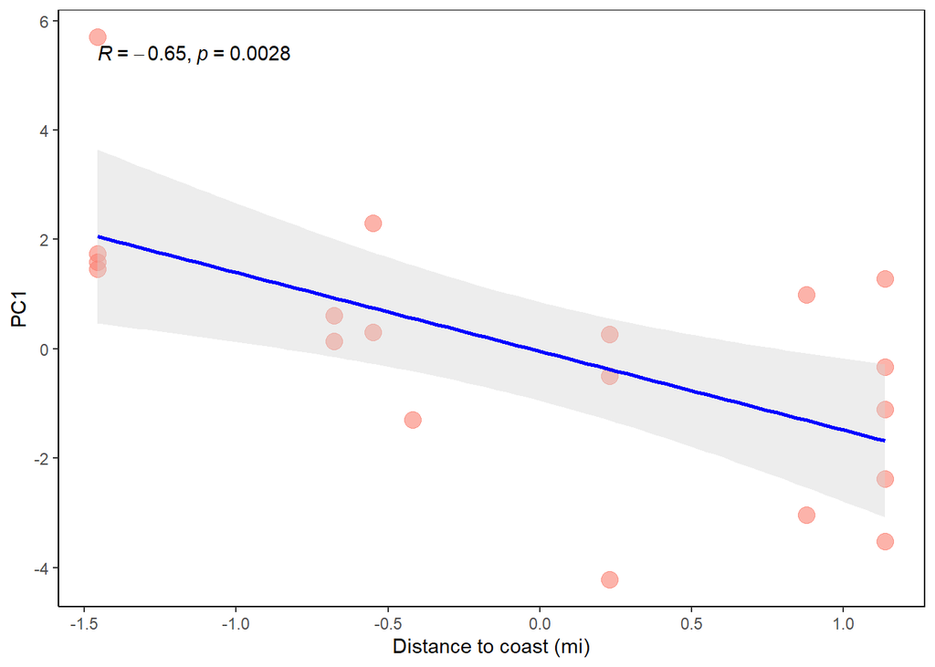

```r
#Scatter plot: distance to coast and fish PC1
scatter <- ggscatter(pc_loadings_fish, x = "DistancetoCoast", y = "PC1", size = 4, color = "#FA8072", alpha = 0.6, repel = FALSE,  font.label = c(9, "plain", "black"),
          add = "reg.line", add.params = list(color = "blue", fill = "lightgray"),
          conf.int = TRUE,
          cor.coef = TRUE, cor.method = "spearman",
          cor.coeff.args = list(method = "spearman", label.x.npc = "left", label.y.npc = "top"),
          xlab = "Distance to coast (mi)", ylab = "PC1")+
  theme_classic() +
  theme(panel.border = element_rect(color = "black", fill = NA), # Adds an outer frame
        axis.line = element_line(color = "black"),               # Keeps axis lines
        panel.grid = element_blank())                            # Ensures no inner grid lines
scatter
```

#PLSR

```r
library(pls)
# Function to calculate VIP scores
calculate_vip <- function(model) {
  W <- model$loading.weights           # Weight matrix
  T <- model$scores                    # Score matrix
  X <- model$model[, -1, drop = FALSE] # Predictor matrix
  Y <- model$model[, 1, drop = TRUE]   # Response variable
  comp <- ncol(T)                      # Number of components
  p <- nrow(W)                         # Number of predictors

  # Total sum of squares for Y
  SSY <- sum((Y - mean(Y))^2)

  # Variance explained per component
  SSY_comp <- sapply(1:comp, function(k) {
    fitted <- model$fitted.values[, , k] # Extract fitted values for component k
    sum((fitted - mean(Y))^2)
  })
  Yvar <- SSY_comp / SSY                 # Proportion of variance explained

  # Compute VIP scores
  vip <- numeric(p)
  for (j in 1:p) {
    vip[j] <- sqrt(p * sum((W[j, ]^2 * Yvar) / sum(Yvar)))
  }

  return(vip)
}
```

#PLSR: Plant-Animal-Ratio, taxa richness, Sharon diversity (Fig 3c,e, Supplementary Fig 6b)

```r
#Make the list
Y_richness <- df_diversity$Observed
Y_Shannon <- df_diversity$Shannon
Y_PAR <- df_diversity$PAR
NCWW_diversity <- list(X_scaled, Y_richness, Y_Shannon, Y_PAR)

# PLSR model Plant-Animal-Ratio ~ Demographics
pls_model <- plsr(Y_PAR ~ X_scaled, ncomp = 10, data = NCWW_diversity, validation = "CV")

# Examine the model summary
summary(pls_model)
```

```
## Data:    X dimension: 39 37
##  Y dimension: 39 1
## Fit method: kernelpls
## Number of components considered: 10
##
## VALIDATION: RMSEP
## Cross-validated using 10 random segments.
##        (Intercept)  1 comps  2 comps  3 comps  4 comps  5 comps  6 comps
## CV          0.8847   0.8833   0.9346   0.9735   0.9974    1.006   1.0149
## adjCV       0.8847   0.8809   0.9255   0.9595   0.9812    0.980   0.9915
##        7 comps  8 comps  9 comps  10 comps
## CV      0.9901    1.024    1.066     1.069
## adjCV   0.9690    1.001    1.037     1.041
##
## TRAINING: % variance explained
##        1 comps  2 comps  3 comps  4 comps  5 comps  6 comps  7 comps  8 comps
## X        38.23    51.77    63.02    68.52    71.53    76.98    81.89    85.88
## Y_PAR    11.71    23.88    30.56    40.31    51.24    53.10    54.82    57.13
##        9 comps  10 comps
## X        88.07     90.44
## Y_PAR    59.58     60.16
```

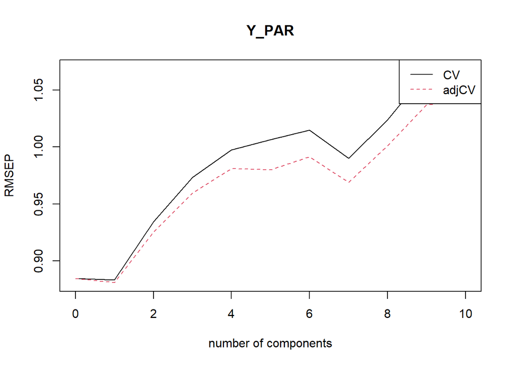

```r
# Cross-validation plot to determine the optimal number of components
plot(RMSEP(pls_model), legendpos = "topright")
```

```r
#Fit the model with optimal components
optimal_components <- which.min(pls_model$validation$PRESS)
pls_model <- plsr(Y_PAR ~ X_scaled, ncomp = optimal_components, data = NCWW_diversity, validation = "CV")
summary(pls_model)
```

```
## Data:    X dimension: 39 37
##  Y dimension: 39 1
## Fit method: kernelpls
## Number of components considered: 1
##
## VALIDATION: RMSEP
## Cross-validated using 10 random segments.
##        (Intercept)  1 comps
## CV          0.8847   0.8893
## adjCV       0.8847   0.8874
##
## TRAINING: % variance explained
##        1 comps
## X        38.23
## Y_PAR    11.71
```

```r
# Calculate VIP scores
vip_scores <- calculate_vip(pls_model)

# calculate RMSE-predicted
RMSEP(pls_model)
```

```
##        (Intercept)  1 comps
## CV          0.8847   0.8893
## adjCV       0.8847   0.8874
```

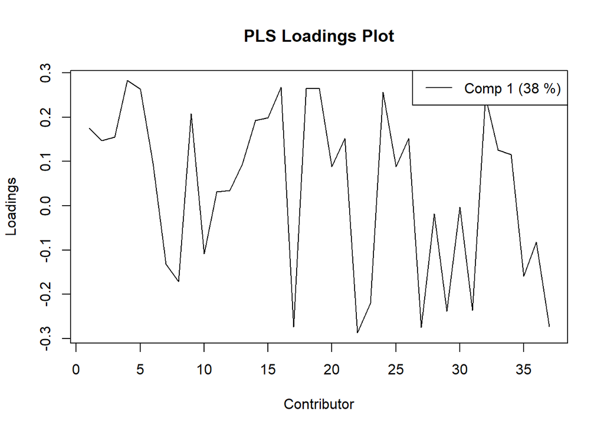

```r
#Plot coefficients
loadingplot(pls_model, comps = 1:optimal_components, legendpos = "topright",
            xlab = "Contributor", ylab = "Loadings",
            main = "PLS Loadings Plot")
```

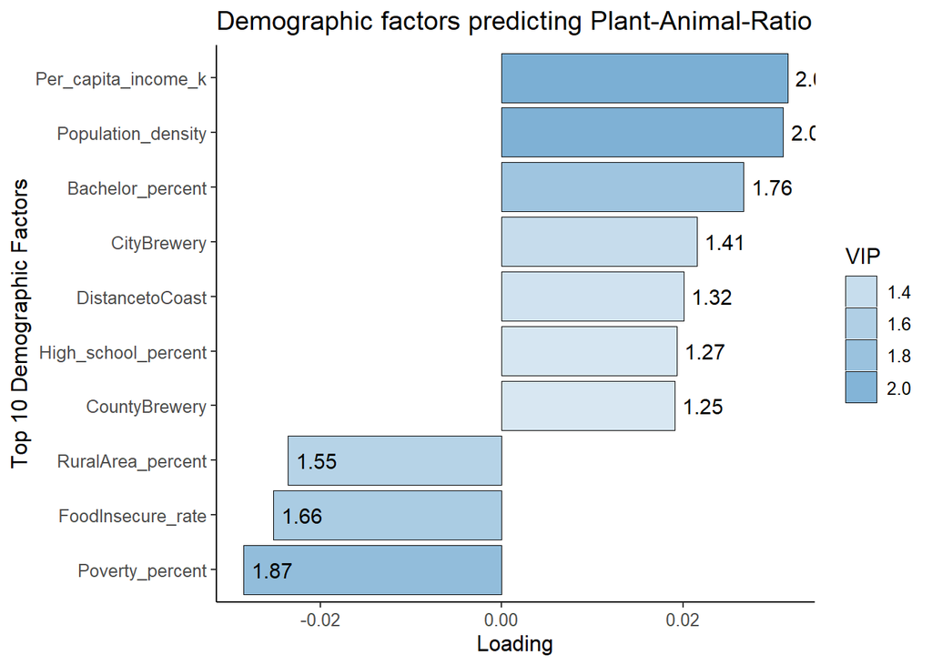

```r
##Plot coeffients
pls.contri <- data.frame(pls_model$coefficients)
pls.contri <- rownames_to_column(pls.contri, var = "Factor")

# Add VIP scores to the data frame
pls.contri <- pls.contri %>%
  mutate(VIP = vip_scores)

# Filter for the top 10 factors with the highest absolute Y_ratio.1.comps
top_factors <- pls.contri %>%
  mutate(abs_value = abs(Y_PAR.1.comps)) %>%  # Create a column for the absolute values
  arrange(desc(abs_value)) %>%  # Sort by absolute value in descending order
  slice(1:10)  # Select the top 10 rows

# Plot with VIP labels
PLSC1_coefficients <- ggplot(top_factors, aes(x = reorder(Factor, Y_PAR.1.comps), y = Y_PAR.1.comps)) +
  geom_bar(stat = "identity", aes(alpha = VIP), fill = "#7BAFD4", color = "black", linewidth = 0.2) + # Bar plot #7BAFD4 for demographic factors
  geom_text(aes(label = round(VIP, 2)),  # Set label position to the 0 line
            hjust = -0.2, size = 4, color = "black") +  # Adjust label alignment and size# Map alpha to VIP
  scale_alpha_continuous(range = c(0.3, 1)) +  # Set transparency range: lower scores are more transparent
  labs(x = "Top 10 Demographic Factors", y = "Loading", title = "Demographic factors predicting Plant-Animal-Ratio") +  # Label chart and axes
  theme_classic() +
  theme(text = element_text(color = "black", size = 12)) +
  coord_flip()

PLSC1_coefficients
```

```r
# PLSR model Shannon Diversity ~ Demographics
pls_model <- plsr(Y_Shannon ~ X_scaled, ncomp = 10, data = NCWW_diversity, validation = "CV")

# Examine the model summary
summary(pls_model)
```

```
## Data:    X dimension: 39 37
##  Y dimension: 39 1
## Fit method: kernelpls
## Number of components considered: 10
##
## VALIDATION: RMSEP
## Cross-validated using 10 random segments.
##        (Intercept)  1 comps  2 comps  3 comps  4 comps  5 comps  6 comps
## CV          0.5818   0.5756   0.5698   0.5932   0.6485   0.7325   0.7194
## adjCV       0.5818   0.5725   0.5649   0.5843   0.6332   0.7060   0.6961
##        7 comps  8 comps  9 comps  10 comps
## CV      0.7151   0.7605   0.7895    0.8416
## adjCV   0.6902   0.7336   0.7598    0.8087
##
## TRAINING: % variance explained
##            1 comps  2 comps  3 comps  4 comps  5 comps  6 comps  7 comps
## X            38.95    54.14    62.75    67.92    71.10    76.12    78.55
## Y_Shannon    20.51    33.79    42.96    51.39    61.54    63.28    65.91
##            8 comps  9 comps  10 comps
## X            84.93    87.59      90.5
## Y_Shannon    66.95    68.37      68.9
```

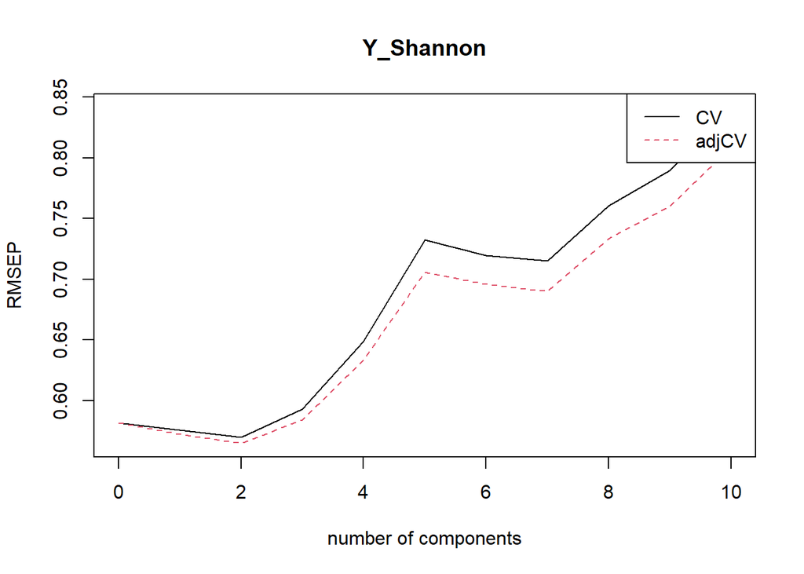

```r
# Cross-validation plot to determine the optimal number of components
plot(RMSEP(pls_model), legendpos = "topright")
```

```r
#Fit the model with optimal components
optimal_components <- which.min(pls_model$validation$PRESS)
pls_model <- plsr(Y_Shannon ~ X_scaled, ncomp = optimal_components, data = NCWW_diversity, validation = "CV")
summary(pls_model)
```

```
## Data:    X dimension: 39 37
##  Y dimension: 39 1
## Fit method: kernelpls
## Number of components considered: 2
##
## VALIDATION: RMSEP
## Cross-validated using 10 random segments.
##        (Intercept)  1 comps  2 comps
## CV          0.5818   0.5542   0.5565
## adjCV       0.5818   0.5524   0.5531
##
## TRAINING: % variance explained
##            1 comps  2 comps
## X            38.95    54.14
## Y_Shannon    20.51    33.79
```

```r
# Calculate VIP scores
vip_scores <- calculate_vip(pls_model)

# Calculate RMSE-predicted
RMSEP(pls_model)
```

```
##        (Intercept)  1 comps  2 comps
## CV          0.5818   0.5542   0.5565
## adjCV       0.5818   0.5524   0.5531
```

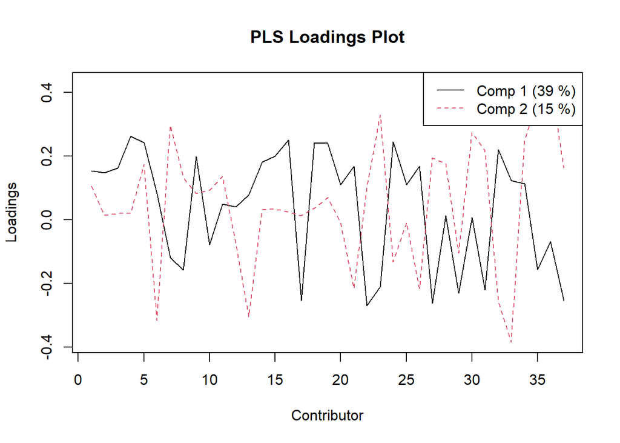

```r
#Plot coefficients
loadingplot(pls_model, comps = 1:optimal_components, legendpos = "topright",
            xlab = "Contributor", ylab = "Loadings",
            main = "PLS Loadings Plot")
```

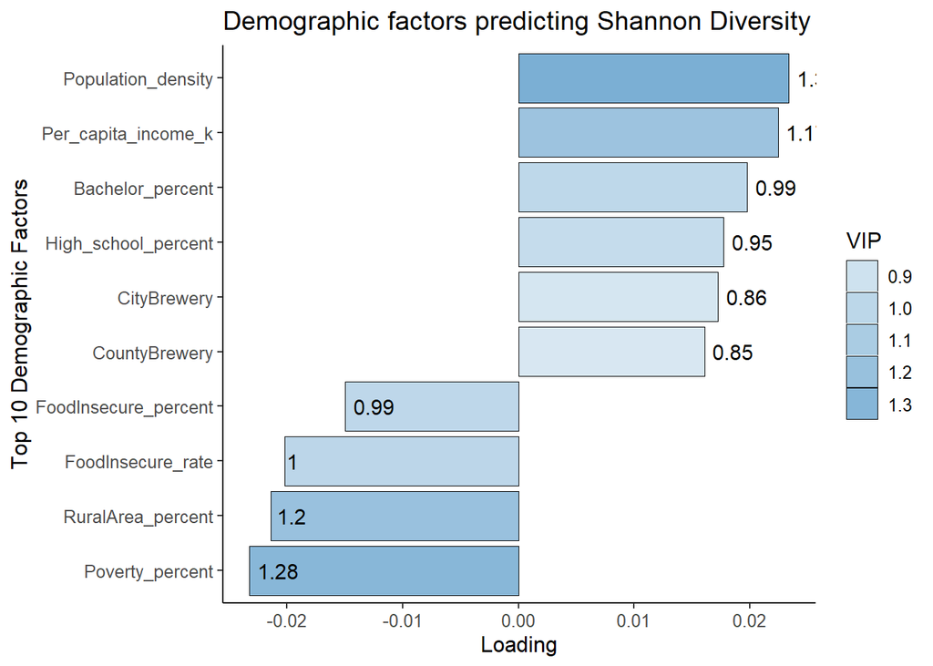

```r
##Plot coeffients
pls.contri <- data.frame(pls_model$coefficients)
pls.contri <- rownames_to_column(pls.contri, var = "Factor")

# Add VIP scores to the data frame
pls.contri <- pls.contri %>%
  mutate(VIP = vip_scores)

# Filter for the top 10 factors with the highest absolute Y_ratio.1.comps
top_factors <- pls.contri %>%
  mutate(abs_value = abs(Y_Shannon.1.comps)) %>%  # Create a column for the absolute values
  arrange(desc(abs_value)) %>%  # Sort by absolute value in descending order
  slice(1:10)  # Select the top 10 rows

# Plot with VIP labels
PLSC1_coefficients <- ggplot(top_factors, aes(x = reorder(Factor, Y_Shannon.1.comps), y = Y_Shannon.1.comps)) +
  geom_bar(stat = "identity", aes(alpha = VIP), fill = "#7BAFD4", color = "black", linewidth = 0.2) + # Bar plot #7BAFD4 for demographic factors
  geom_text(aes(label = round(VIP, 2)),  # Set label position to the 0 line
            hjust = -0.2, size = 4, color = "black") +  # Adjust label alignment and size# Map alpha to VIP
  scale_alpha_continuous(range = c(0.3, 1)) +  # Set transparency range: lower scores are more transparent
  labs(x = "Top 10 Demographic Factors", y = "Loading", title = "Demographic factors predicting Shannon Diversity") +  # Label chart and axes
  theme_classic() +
  theme(text = element_text(color = "black", size = 12)) +
  coord_flip()

PLSC1_coefficients
```

```r
# PLSR model Richness ~ Demographics
pls_model <- plsr(Y_richness ~ X_scaled, ncomp = 10, data = NCWW_diversity, validation = "CV")

# Examine the model summary
summary(pls_model)
```

```
## Data:    X dimension: 39 37
##  Y dimension: 39 1
## Fit method: kernelpls
## Number of components considered: 10
##
## VALIDATION: RMSEP
## Cross-validated using 10 random segments.
##        (Intercept)  1 comps  2 comps  3 comps  4 comps  5 comps  6 comps
## CV           8.902    7.878    7.230    7.219    7.484    8.279    8.704
## adjCV        8.902    7.860    7.194    7.119    7.371    8.102    8.504
##        7 comps  8 comps  9 comps  10 comps
## CV       8.884    8.893    9.013     9.343
## adjCV    8.675    8.686    8.803     9.110
##
## TRAINING: % variance explained
##             1 comps  2 comps  3 comps  4 comps  5 comps  6 comps  7 comps
## X             35.20    54.77    63.31    69.91    72.74    76.11    80.05
## Y_richness    33.69    53.05    63.55    65.98    67.71    68.40    68.58
##             8 comps  9 comps  10 comps
## X             82.36    88.03     91.33
## Y_richness    68.74    68.79     68.84
```

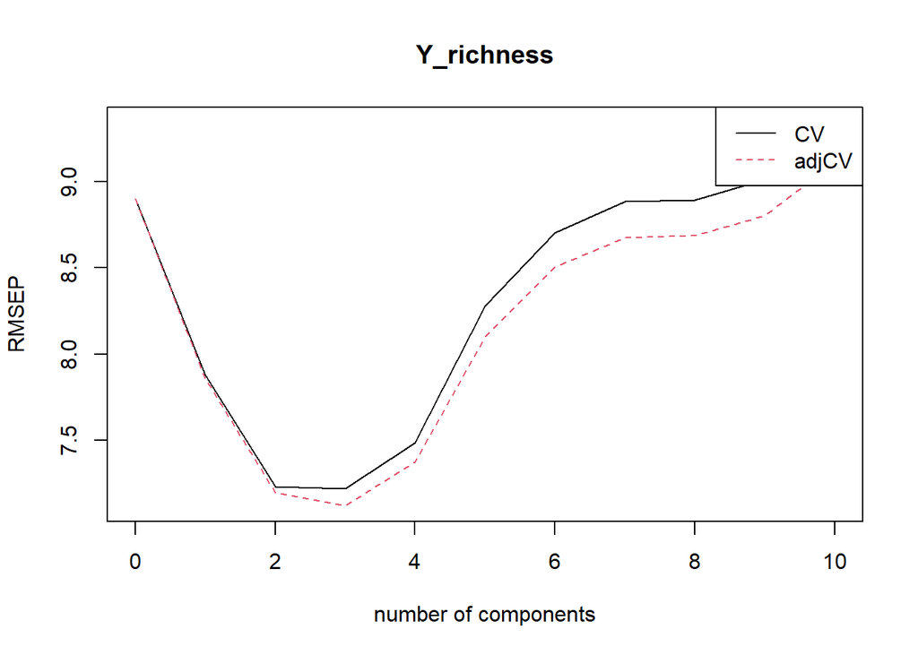

```r
# Cross-validation plot to determine the optimal number of components
plot(RMSEP(pls_model), legendpos = "topright")
```

```r
#Fit the model with optimal components
optimal_components <- which.min(pls_model$validation$PRESS)
pls_model <- plsr(Y_richness ~ X_scaled, ncomp = optimal_components, data = NCWW_diversity, validation = "CV")
summary(pls_model)
```

```
## Data:    X dimension: 39 37
##  Y dimension: 39 1
## Fit method: kernelpls
## Number of components considered: 3
##
## VALIDATION: RMSEP
## Cross-validated using 10 random segments.
##        (Intercept)  1 comps  2 comps  3 comps
## CV           8.902    7.969    7.445    7.443
## adjCV        8.902    7.939    7.389    7.333
##
## TRAINING: % variance explained
##             1 comps  2 comps  3 comps
## X             35.20    54.77    63.31
## Y_richness    33.69    53.05    63.55
```

```r
# Calculate VIP scores
vip_scores <- calculate_vip(pls_model)

# Calculate RMSE-predicted
RMSEP(pls_model)
```

```
##        (Intercept)  1 comps  2 comps  3 comps
## CV           8.902    7.969    7.445    7.443
## adjCV        8.902    7.939    7.389    7.333
```

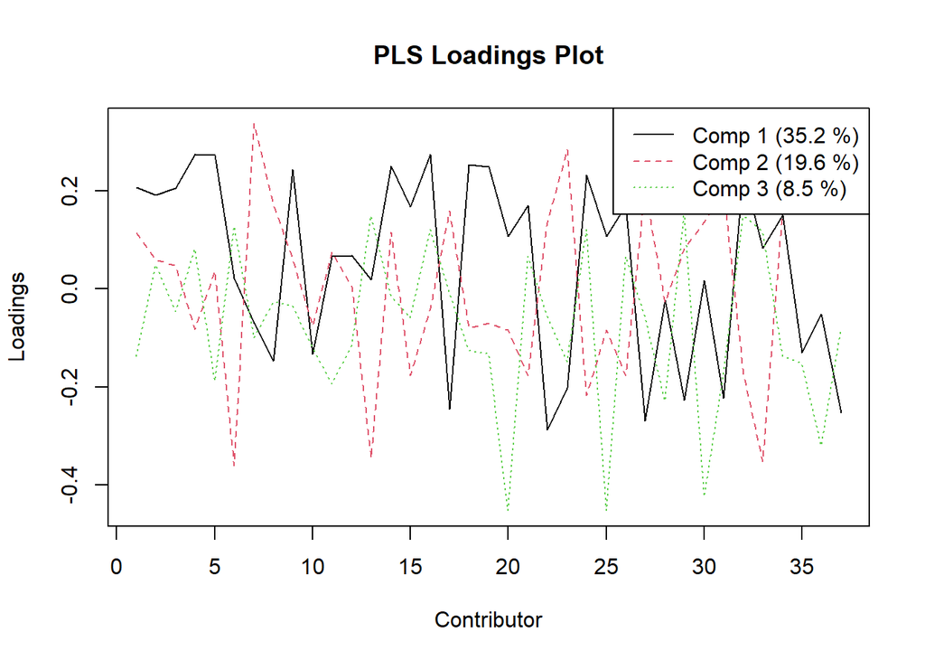

```r
#Plot coefficients
loadingplot(pls_model, comps = 1:optimal_components, legendpos = "topright",
            xlab = "Contributor", ylab = "Loadings",
            main = "PLS Loadings Plot")
```

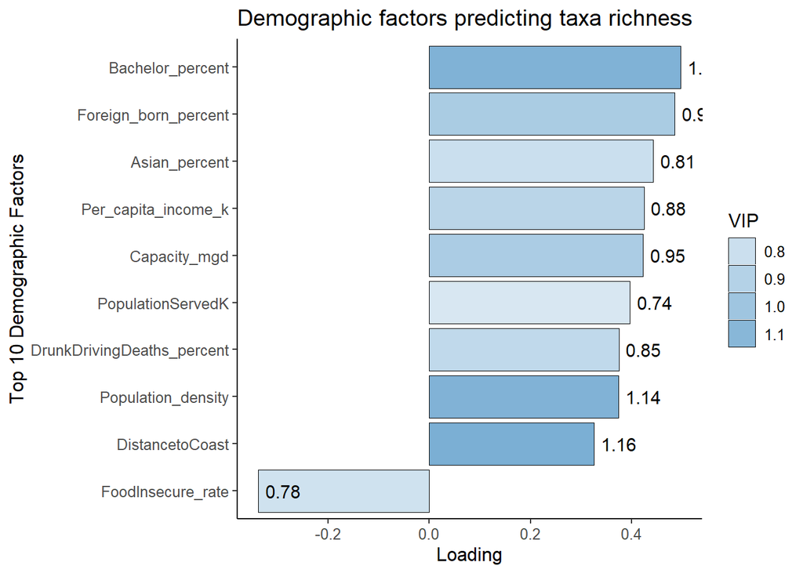

```r
##Plot coeffients
pls.contri <- data.frame(pls_model$coefficients)
pls.contri <- rownames_to_column(pls.contri, var = "Factor")

# Add VIP scores to the data frame
pls.contri <- pls.contri %>%
  mutate(VIP = vip_scores)

# Filter for the top 10 factors with the highest absolute Y_ratio.1.comps
top_factors <- pls.contri %>%
  mutate(abs_value = abs(Y_richness.1.comps)) %>%  # Create a column for the absolute values
  arrange(desc(abs_value)) %>%  # Sort by absolute value in descending order
  slice(1:10)  # Select the top 10 rows

# Plot with VIP labels
PLSC1_coefficients <- ggplot(top_factors, aes(x = reorder(Factor, Y_richness.1.comps), y = Y_richness.1.comps)) +
  geom_bar(stat = "identity", aes(alpha = VIP), fill = "#7BAFD4", color = "black", linewidth = 0.2) + # Bar plot #7BAFD4 for demographic factors
  geom_text(aes(label = round(VIP, 2)),  # Set label position to the 0 line
            hjust = -0.2, size = 4, color = "black") +  # Adjust label alignment and size# Map alpha to VIP
  scale_alpha_continuous(range = c(0.3, 1)) +  # Set transparency range: lower scores are more transparent
  labs(x = "Top 10 Demographic Factors", y = "Loading", title = "Demographic factors predicting taxa richness") +  # Label chart and axes
  theme_classic() +
  theme(text = element_text(color = "black", size = 12)) +
  coord_flip()

PLSC1_coefficients
```

#PLSR: plant PC ~ Demographic (Fig 4d,e)

```r
#Picking up from PCA pc_loadings
pc_loadings_plant
```

[output not shown]

[output cut: 265 more lines]

```r
##PCs from plant PCA
Y1 <- pc_loadings_plant$PC1
Y2 <- pc_loadings_plant$PC2

NCWW_plantPC <- list(Demographics_scaled, Y1, Y2)

# Fit the PLS model
pls_model <- plsr(Y1 ~ Demographics_scaled, ncomp = 10, data = NCWW_plantPC, validation = "CV")

# Examine the model summary
summary(pls_model)
```

```
## Data:    X dimension: 19 37
##  Y dimension: 19 1
## Fit method: kernelpls
## Number of components considered: 10
##
## VALIDATION: RMSEP
## Cross-validated using 10 random segments.
##        (Intercept)  1 comps  2 comps  3 comps  4 comps  5 comps  6 comps
## CV           5.774    4.239    5.083    5.141    4.875    4.760    5.112
## adjCV        5.774    4.215    4.972    4.953    4.682    4.573    4.862
##        7 comps  8 comps  9 comps  10 comps
## CV       5.296    5.437    5.600     5.631
## adjCV    5.035    5.169    5.307     5.333
##
## TRAINING: % variance explained
##     1 comps  2 comps  3 comps  4 comps  5 comps  6 comps  7 comps  8 comps
## X     41.21    53.55    61.49    67.45    72.24    74.80    79.85    85.83
## Y1    58.74    75.00    87.23    91.77    93.93    97.07    97.91    98.33
##     9 comps  10 comps
## X     87.94     90.11
## Y1    99.12     99.41
```

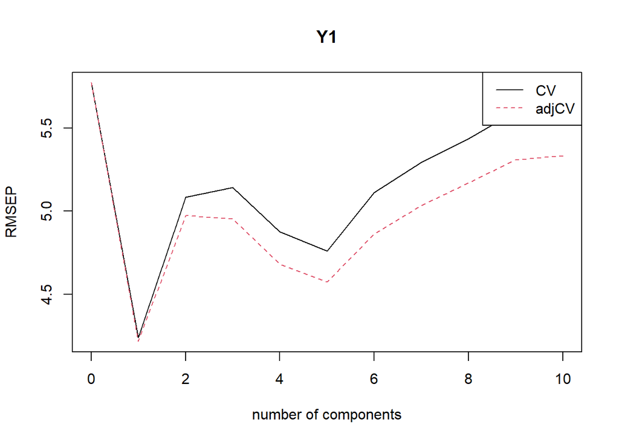

```r
# Cross-validation plot to determine the optimal number of components
plot(RMSEP(pls_model), legendpos = "topright")
```

```r
#Fit the model with optimal components
optimal_components <- which.min(pls_model$validation$PRESS)
pls_model <- plsr(Y1 ~Demographics_scaled, ncomp = optimal_components, data = NCWW_plantPC, validation = "CV")
summary(pls_model)
```

```
## Data:    X dimension: 19 37
##  Y dimension: 19 1
## Fit method: kernelpls
## Number of components considered: 1
##
## VALIDATION: RMSEP
## Cross-validated using 10 random segments.
##        (Intercept)  1 comps
## CV           5.774    4.032
## adjCV        5.774    4.015
##
## TRAINING: % variance explained
##     1 comps
## X     41.21
## Y1    58.74
```

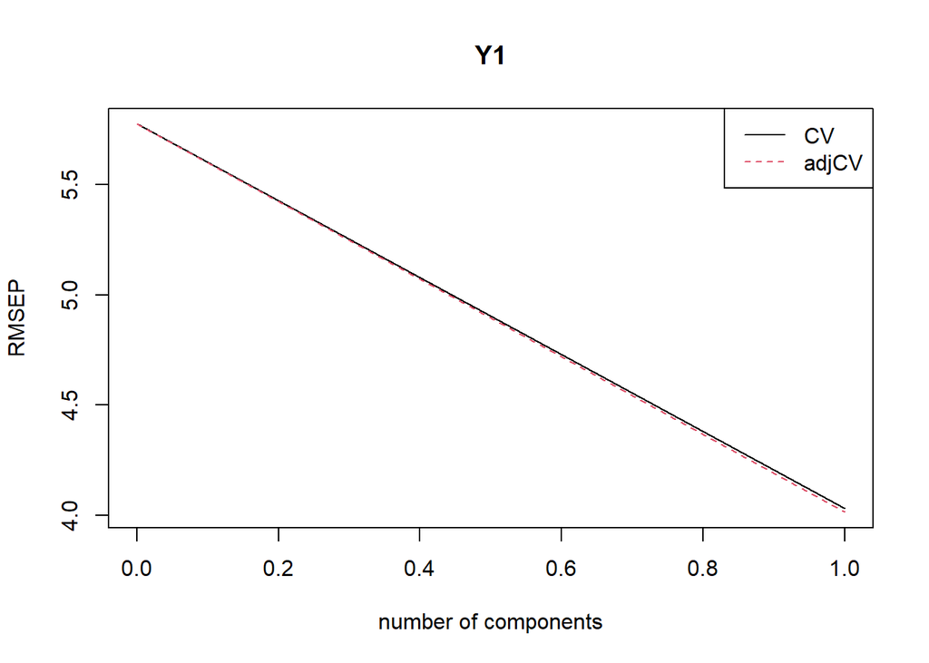

```r
plot(RMSEP(pls_model), legendpos = "topright")
```

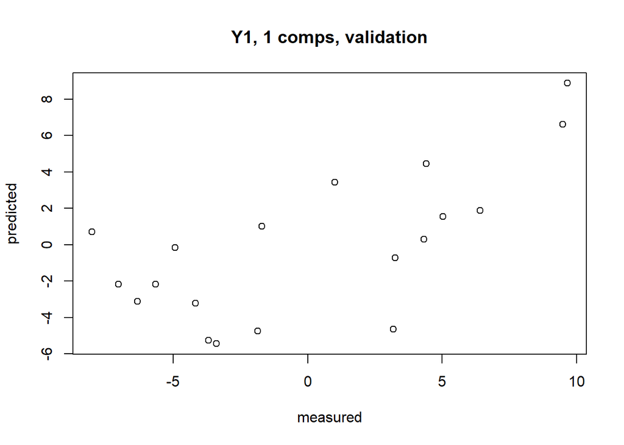

```r
# Plot results
plot(pls_model)
```

```r
RMSEP(pls_model)
```

```
##        (Intercept)  1 comps
## CV           5.774    4.032
## adjCV        5.774    4.015
```

```r
# Calculate VIP scores
vip_scores <- calculate_vip(pls_model)
vip_scores
```

```
##  [1] 0.05698973 0.61901479 0.61825228 1.38757485 0.76336929 1.08578139
##  [7] 0.98442048 0.89208026 0.01224948 0.28329209 0.57289859 0.27187208
## [13] 1.01456680 0.46289016 0.89985163 1.04484988 1.06767577 1.05274139
## [19] 1.06422653 0.21500923 0.81905702 1.37908276 1.56461230 1.57595999
## [25] 0.21500923 0.81905702 1.48969026 0.31818068 1.28663497 0.55897067
## [31] 1.53748741 1.16324214 1.28443741 0.35708288 1.49802873 1.02484533
## [37] 1.55768684
```